# Association of Actigraphy-Measured Rest-Activity Rhythms with Obesity Phenotypes in the Osteoporotic Fractures in Men (MrOS) Study

Hajin Jang

3/13/2025

# Abstract

**Background:** Obesity in older adults presents as whole-body, abdominal, or sarcopenic obesity. Disruptions in rest-activity rhythms (RAR) are linked to metabolic disorders, but their role in obesity phenotypes among older men is unclear. This study examines the association between RAR and obesity phenotypes in older men from the Osteoporotic Fractures in Men (MrOS) Study.

**Methods:** This study utilized MrOS 2000-2016 data. A total of 2,989 men aged 65 and older with valid actigraphy, anthropometric, and physical function data, followed up at least once were included. RAR parameters were assessed using wrist-worn actigraphy. RAR variables were categorized into quartiles, where higher amplitude, mesor, interdaily stability (IS), F-statistics, and relative amplitude (RA), as well as lower intradaily variability (IV) and mid-range acrophase, reflect healthier activity rhythms. Obesity phenotypes were classified as whole-body obesity, abdominal, and sarcopenic obesity. Generalized estimating equations models were used to evaluate longitudinal associations between RAR and obesity phenotypes.

**Results:** Lower amplitude, mesor, F-statistics, IS, and RA, as well as earlier acrophase and higher IV, were associated with higher odds of whole-body and abdominal obesity. Associations were generally weaker and less consistent for sarcopenic obesity, though RA remained strongly associated across all obesity types. For example, the lowest quartile of RA compared to the highest quartile was associated with whole-body (OR = 5.62, 95% CI: 4.18-7.56), abdominal (OR= 3.93, 95% CI: 3.17-4.86), and sarcopenic obesity (OR = 3.39, 95% CI: 2.47-4.64).

**Conclusion:** Disrupted RARs may play a role in weight gain and metabolic dysfunction. Irregular activity patterns and reduced day-night variations could be linked to declines in muscle function. Enhancing activity levels and stabilizing RARs could help prevent and manage obesity in aging populations.

```r
library(readr)
library(tidyverse)
library(patchwork)
library(geepack)
```

# data importing

```r
mros <- read_csv("Data/mros_noNA_wideformat.csv")
mros.l <- read_csv("mros_longformat_v2.csv")
# Convert variables to factors
mros.l <- mros.l %>%
  mutate(
    ID = as.factor(ID),
    slpmed = as.factor(slpmed),
    educat = as.factor(educat),
    racecat = as.factor(racecat),
    site = as.factor(site),
    alc = as.factor(alc),
    smk = as.factor(smk),
    ampQQT = as.factor(ampQQT),
    acroQQT = as.factor(acroQQT),
    mesQQT = as.factor(mesQQT),
    fvalQQT = as.factor(fvalQQT),
    isQQT = as.factor(isQQT),
    ivQQT = as.factor(ivQQT),
    raQQT = as.factor(raQQT)
  )

str(mros.l)
```

```
## tibble [5,978 × 62] (S3: tbl_df/tbl/data.frame)
##  $ ID         : Factor w/ 2989 levels "BI0001","BI0002",..: 1 1 2 2 3 3 4 4 5 5 ...
##  $ totslp     : num [1:5978] 6 6 7 7 6 6 5 5 7 7 ...
##  $ slpmed     : Factor w/ 4 levels "0","1","2","3": 2 2 4 4 1 1 4 4 4 4 ...
##  $ alc        : Factor w/ 6 levels "0","1","2","3",..: 1 1 1 1 3 3 2 2 1 1 ...
##  $ caf        : num [1:5978] 356 356 272 272 272 272 272 272 0 0 ...
##  $ educat     : Factor w/ 3 levels "1","2","3": 3 3 3 3 3 3 3 3 1 1 ...
##  $ racecat    : Factor w/ 5 levels "1","2","3","4",..: 1 1 1 1 1 1 1 1 1 1 ...
##  $ acrophase  : num [1:5978] 13.4 13.4 16.7 16.7 14.2 ...
##  $ amplitude  : num [1:5978] 4442 4442 3612 3612 2644 ...
##  $ mesor      : num [1:5978] 2221 2221 2270 2270 1705 ...
##  $ fstat      : num [1:5978] 1597 1597 1434 1434 1118 ...
##  $ is         : num [1:5978] 0.786 0.786 0.788 0.788 0.746 ...
##  $ iv         : num [1:5978] 0.474 0.474 0.575 0.575 0.609 ...
##  $ relativeamp: num [1:5978] 0.895 0.895 0.869 0.869 0.795 ...
```

[output cut: 48 more lines]

```r
mros.l <- mros.l %>%
  mutate(ampQQT = relevel(ampQQT,4),
         acroQQT = relevel(acroQQT,2),
         mesQQT = relevel(mesQQT,4),
         fvalQQT = relevel(fvalQQT,4),
         isQQT = relevel(isQQT,4),
         ivQQT = relevel(ivQQT,1),
         raQQT = relevel(raQQT,4),
         racecat = relevel(racecat, 1),
         educat = relevel(educat, 2),
         smk = relevel(smk, 1),
         alc = relevel(alc, 1),
         slpmed = relevel(slpmed, 1)
         )
```

# check main outcomes

```r
# Summarize binary outcomes across visits
binary_outcome_summary <- mros.l %>%
  group_by(visit) %>%
  summarise(
    wbobe_rate = mean(as.numeric(as.character(wbobe)), na.rm = TRUE),  # Convert factor to numeric
    abobe_rate = mean(as.numeric(as.character(abobe)), na.rm = TRUE),
    saobe_rate = mean(as.numeric(as.character(saobe)), na.rm = TRUE),
    n = n()
  ) %>%
  ungroup()

# Print summary
print(binary_outcome_summary)
```

```
## # A tibble: 2 × 5
##   visit wbobe_rate abobe_rate saobe_rate     n
##   <dbl>      <dbl>      <dbl>      <dbl> <int>
## 1     1      0.207      0.395     0.0960  2989
## 2     3      0.165      0.359     0.119   2989
```

# trajectory plot

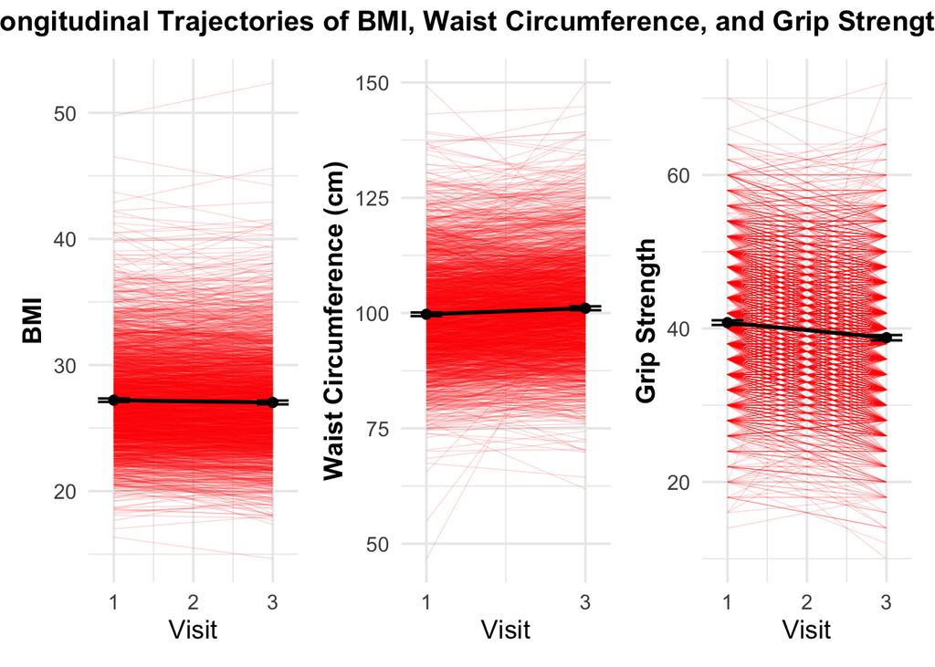

```r
# Function to generate trajectory plots for a given variable (without titles)
plot_trajectory <- function(data, variable, y_label, x_breaks) {
  plot_data <- data %>%
    group_by(visit) %>%
    summarize(
      n = sum(!is.na(.data[[variable]])),
      mean = mean(.data[[variable]], na.rm = TRUE),
      sd = sd(.data[[variable]], na.rm = TRUE),
      se = sd / sqrt(n)
    )

  ggplot(plot_data, aes(x = visit, y = mean)) +
    # Individual trajectories in light red
    geom_line(data = data %>% drop_na(.data[[variable]]),
              aes(x = visit, y = .data[[variable]], group = ID),
              color = "red", linewidth = 0.2, alpha = 0.2) +
    # Error bars for mean ±1.96*SE
    geom_errorbar(aes(ymin = mean - 1.96 * se, ymax = mean + 1.96 * se),
                  width = 0.4) +
    geom_point(size = 2) +
    geom_line(linewidth = 1) +
    labs(x = "Visit", y = y_label) +  # No title
    scale_x_continuous(breaks = x_breaks) +
    theme_minimal(base_size = 14) +
    theme(plot.title = element_blank(),  # Remove individual titles
          axis.title.y = element_text(size = 14, face = "bold"))
}

# Generate trajectory plots (without individual titles)
plot_bmi <- plot_trajectory(mros.l, "bmi", "BMI", c(1, 2, 3, 4))
plot_waist <- plot_trajectory(mros.l %>% filter(visit %in% c(1, 3)),
                              "waist", "Waist Circumference (cm)", c(1, 3))
plot_maxgs <- plot_trajectory(mros.l, "maxgs", "Grip Strength", c(1, 2, 3, 4))

# Combine the three plots into one figure
combined_plot <- (plot_bmi | plot_waist | plot_maxgs) +
  plot_annotation(title = "Longitudinal Trajectories of BMI, Waist Circumference, and Grip Strength",
                  theme = theme(plot.title = element_text(size = 15, face = "bold", hjust = 0.5)))

# Display the combined plot
print(combined_plot)
```

# GLMM

```r
# make visit a factor variable
mros.l = mros.l %>% dplyr::mutate(visit = as.factor(visit))

# random intercept model with interaction term
wbobe.ri.int = lme4::glmer(formula = wbobe ~  acrophase + visit + acrophase*visit + (1 | ID),
                         data = mros.l, family = binomial)
summary(wbobe.ri.int)
```

```
## Generalized linear mixed model fit by maximum likelihood (Laplace
##   Approximation) [glmerMod]
##  Family: binomial  ( logit )
## Formula: wbobe ~ acrophase + visit + acrophase * visit + (1 | ID)
##    Data: mros.l
##
##       AIC       BIC    logLik -2*log(L)  df.resid
##    3682.9    3716.4   -1836.5    3672.9      5973
##
## Scaled residuals:
##      Min       1Q   Median       3Q      Max
## -1.65614 -0.01255 -0.00496 -0.00434  1.84571
##
## Random effects:
##  Groups Name        Variance Std.Dev.
##  ID     (Intercept) 245      15.65
## Number of obs: 5978, groups:  ID, 2989
##
## Fixed effects:
##                  Estimate Std. Error z value Pr(>|z|)
## (Intercept)      -7.97989    1.88903  -4.224  2.4e-05 ***
## acrophase        -0.05096    0.13156  -0.387    0.698
## visit3           -0.74556    2.27834  -0.327    0.743
## acrophase:visit3 -0.08707    0.16044  -0.543    0.587
## ---
## Signif. codes:  0 '***' 0.001 '**' 0.01 '*' 0.05 '.' 0.1 ' ' 1
##
## Correlation of Fixed Effects:
##             (Intr) acrphs visit3
## acrophase   -0.992
## visit3      -0.175  0.174
## acrphs:vst3  0.176 -0.174 -0.996
```

```r
# standardize acrophase
mros.l <- mros.l %>%
  mutate(acrophase_s = scale(acrophase))

wbobe.ri.int = lme4::glmer(
  wbobe ~ acrophase_s + visit + acrophase_s * visit + (1 | ID),
  data = mros.l,
  family = binomial
)
```

# GEE

## whole-body obesity

```r
mros.l <- mros.l[complete.cases(mros.l[, c("age", "racecat", "educat")]), ]
mros.f <- mros.l[complete.cases(mros.l[, c("age", "racecat", "educat", "alc", "totslp", "slpmed", "caf", "pase", "dep", "smk")]), ]

## Whole-body obesity
### Acrophase
acrophase_gee1 <- geeglm(wbobe ~ acroQQT + visit + age + racecat + educat,
                    data = mros.l,
                    id = ID,
                    family = binomial,
                    corstr = "exchangeable")
summary(acrophase_gee1)
```

```
##
## Call:
## geeglm(formula = wbobe ~ acroQQT + visit + age + racecat + educat,
##     family = binomial, data = mros.l, id = ID, corstr = "exchangeable")
##
##  Coefficients:
##                  Estimate    Std.err     Wald Pr(>|W|)
## (Intercept)      4.016229   0.637766   39.656 3.03e-10 ***
## acroQQTGroup 1   0.470029   0.175270    7.192  0.00732 **
## acroQQTGroup 3   0.150097   0.195443    0.590  0.44250
## visit3           0.069919   0.046141    2.296  0.12969
## age             -0.066029   0.008291   63.420 1.67e-15 ***
## racecat2         0.242116   0.207425    1.362  0.24311
## racecat3       -36.211531   0.711637 2589.263  < 2e-16 ***
## racecat4        -1.184523   0.395881    8.953  0.00277 **
## racecat5         0.154208   0.416757    0.137  0.71137
## educat1          0.283302   0.195329    2.104  0.14695
## educat3         -0.517577   0.113822   20.678 5.43e-06 ***
## ---
## Signif. codes:  0 '***' 0.001 '**' 0.01 '*' 0.05 '.' 0.1 ' ' 1
##
## Correlation structure = exchangeable
## Estimated Scale Parameters:
##
##             Estimate Std.err
## (Intercept)    0.989 0.05545
##   Link = identity
##
## Estimated Correlation Parameters:
##       Estimate Std.err
## alpha   0.7186 0.04598
## Number of clusters:   2944  Maximum cluster size: 2
```

```r
acrophase_gee1_results <- broom::tidy(acrophase_gee1, conf.int = TRUE) %>%
  mutate(
    estimate = exp(estimate),
    conf.low = exp(conf.low),
    conf.high = exp(conf.high)
  )

write.csv(acrophase_gee1_results, "results/acrophase.csv", row.names = FALSE)

acrophase_gee2 <- geeglm(wbobe ~ acroQQT + visit + age + racecat + educat + alc + totslp + slpmed + caf + smk + pase + dep,
                    data = mros.f,
                    id = ID,
                    family = binomial,
                    corstr = "exchangeable")
summary(acrophase_gee2)
```

```
##
## Call:
## geeglm(formula = wbobe ~ acroQQT + visit + age + racecat + educat +
##     alc + totslp + slpmed + caf + smk + pase + dep, family = binomial,
##     data = mros.f, id = ID, corstr = "exchangeable")
##
##  Coefficients:
##                 Estimate   Std.err  Wald Pr(>|W|)
## (Intercept)     4.37e+00  7.19e-01 36.84  1.3e-09 ***
## acroQQTGroup 1  4.53e-01  1.77e-01  6.56  0.01041 *
## acroQQTGroup 3  8.77e-02  2.00e-01  0.19  0.66038
## visit3          5.87e-02  4.67e-02  1.58  0.20884
## age            -6.91e-02  8.61e-03 64.48  1.0e-15 ***
## racecat2        2.17e-01  2.10e-01  1.07  0.30030
## racecat3       -3.62e+01       NaN   NaN      NaN
## racecat4       -1.25e+00  4.00e-01  9.76  0.00178 **
## racecat5        1.45e-01  4.09e-01  0.13  0.72351
## educat1         1.61e-01  1.99e-01  0.65  0.41922
## educat3        -4.64e-01  1.18e-01 15.43  8.6e-05 ***
## alc1            1.20e-01  1.46e-01  0.67  0.41196
## alc2            3.46e-02  1.43e-01  0.06  0.80850
## alc3           -4.81e-02  1.37e-01  0.12  0.72623
## alc4           -4.03e-01  1.35e-01  8.86  0.00292 **
## alc5           -2.15e-01  2.11e-01  1.04  0.30876
## totslp         -5.40e-03  3.86e-02  0.02  0.88871
## slpmed1        -1.41e-01  1.84e-01  0.59  0.44274
## slpmed2        -1.71e-02  2.49e-01  0.00  0.94523
## slpmed3        -1.29e-01  1.49e-01  0.75  0.38798
## caf             3.88e-04  1.75e-04  4.92  0.02660 *
## smk1            1.60e-01  9.60e-02  2.78  0.09561 .
## smk2            1.19e-01  3.25e-01  0.13  0.71501
## pase           -1.62e-03  4.53e-04 12.81  0.00034 ***
## dep             1.42e-02  1.57e-02  0.82  0.36449
## ---
## Signif. codes:  0 '***' 0.001 '**' 0.01 '*' 0.05 '.' 0.1 ' ' 1
##
## Correlation structure = exchangeable
## Estimated Scale Parameters:
##
##             Estimate Std.err
## (Intercept)    0.984  0.0599
##   Link = identity
##
## Estimated Correlation Parameters:
##       Estimate Std.err
## alpha    0.723   0.049
## Number of clusters:   2929  Maximum cluster size: 2
```

```r
acrophase_gee2_results <- broom::tidy(acrophase_gee2, conf.int = TRUE) %>%
  mutate(
    estimate = exp(estimate),
    conf.low = exp(conf.low),
    conf.high = exp(conf.high)
  )
write.csv(acrophase_gee2_results, "results/acrophase_adj.csv", row.names = FALSE)

### Amplitude
amp_gee1 <- geeglm(wbobe ~ ampQQT + visit + age + racecat + educat,
                    data = mros.l,
                    id = ID,
                    family = binomial,
                    corstr = "exchangeable")
summary(amp_gee1)
```

```
##
## Call:
## geeglm(formula = wbobe ~ ampQQT + visit + age + racecat + educat,
##     family = binomial, data = mros.l, id = ID, corstr = "exchangeable")
##
##  Coefficients:
##                  Estimate  Std.err    Wald Pr(>|W|)
## (Intercept)        4.6871   0.6423   53.26  2.9e-13 ***
## ampQQTQuartile 1   0.8351   0.1301   41.22  1.4e-10 ***
## ampQQTQuartile 2   0.4070   0.1317    9.55   0.0020 **
## ampQQTQuartile 3   0.1654   0.1352    1.50   0.2212
## visit3             0.1137   0.0468    5.90   0.0152 *
## age               -0.0790   0.0085   86.38  < 2e-16 ***
## racecat2           0.2210   0.2119    1.09   0.2970
## racecat3         -36.1837   0.7129 2576.09  < 2e-16 ***
## racecat4          -1.1973   0.3930    9.28   0.0023 **
## racecat5           0.1223   0.4073    0.09   0.7639
## educat1            0.2665   0.1979    1.81   0.1782
## educat3           -0.5434   0.1145   22.54  2.1e-06 ***
## ---
## Signif. codes:  0 '***' 0.001 '**' 0.01 '*' 0.05 '.' 0.1 ' ' 1
##
## Correlation structure = exchangeable
## Estimated Scale Parameters:
##
##             Estimate Std.err
## (Intercept)    0.984  0.0578
##   Link = identity
##
## Estimated Correlation Parameters:
##       Estimate Std.err
## alpha    0.718  0.0481
## Number of clusters:   2944  Maximum cluster size: 2
```

```r
amp_gee1_results <- broom::tidy(amp_gee1, conf.int = TRUE) %>%
  mutate(
    estimate = exp(estimate),
    conf.low = exp(conf.low),
    conf.high = exp(conf.high)
  )

write.csv(amp_gee1_results, "results/amplitude.csv", row.names = FALSE)

amp_gee2 <- geeglm(wbobe ~ ampQQT + visit + age + racecat + educat + alc + totslp + slpmed + caf + smk + pase + dep,
                    data = mros.f,
                    id = ID,
                    family = binomial,
                    corstr = "exchangeable")
summary(amp_gee2)
```

```
##
## Call:
## geeglm(formula = wbobe ~ ampQQT + visit + age + racecat + educat +
##     alc + totslp + slpmed + caf + smk + pase + dep, family = binomial,
##     data = mros.f, id = ID, corstr = "exchangeable")
##
##  Coefficients:
##                   Estimate   Std.err  Wald Pr(>|W|)
## (Intercept)       4.83e+00  7.22e-01 44.68  2.3e-11 ***
## ampQQTQuartile 1  7.66e-01  1.35e-01 32.22  1.4e-08 ***
## ampQQTQuartile 2  3.74e-01  1.35e-01  7.73   0.0054 **
## ampQQTQuartile 3  1.32e-01  1.38e-01  0.92   0.3376
## visit3            1.01e-01  4.72e-02  4.59   0.0322 *
## age              -7.93e-02  8.76e-03 82.02  < 2e-16 ***
## racecat2          2.10e-01  2.13e-01  0.97   0.3249
## racecat3         -3.62e+01       NaN   NaN      NaN
## racecat4         -1.25e+00  3.99e-01  9.88   0.0017 **
## racecat5          1.09e-01  4.07e-01  0.07   0.7886
## educat1           1.47e-01  2.01e-01  0.54   0.4622
## educat3          -5.02e-01  1.19e-01 17.90  2.3e-05 ***
## alc1              1.29e-01  1.47e-01  0.76   0.3827
## alc2              5.84e-03  1.43e-01  0.00   0.9674
## alc3             -1.27e-02  1.39e-01  0.01   0.9268
## alc4             -3.42e-01  1.37e-01  6.26   0.0123 *
## alc5             -1.67e-01  2.17e-01  0.59   0.4424
## totslp           -8.62e-03  3.90e-02  0.05   0.8251
## slpmed1          -1.20e-01  1.86e-01  0.42   0.5180
## slpmed2          -2.83e-02  2.55e-01  0.01   0.9117
## slpmed3          -1.32e-01  1.52e-01  0.76   0.3843
## caf               4.34e-04  1.76e-04  6.05   0.0139 *
## smk1              1.53e-01  9.68e-02  2.49   0.1147
## smk2              8.10e-02  3.23e-01  0.06   0.8019
## pase             -1.28e-03  4.63e-04  7.64   0.0057 **
## dep               7.79e-03  1.59e-02  0.24   0.6249
## ---
## Signif. codes:  0 '***' 0.001 '**' 0.01 '*' 0.05 '.' 0.1 ' ' 1
##
## Correlation structure = exchangeable
## Estimated Scale Parameters:
##
##             Estimate Std.err
## (Intercept)    0.981  0.0605
##   Link = identity
##
## Estimated Correlation Parameters:
##       Estimate Std.err
## alpha    0.723  0.0498
## Number of clusters:   2929  Maximum cluster size: 2
```

```r
amp_gee2_results <- broom::tidy(amp_gee2, conf.int = TRUE) %>%
  mutate(
    estimate = exp(estimate),
    conf.low = exp(conf.low),
    conf.high = exp(conf.high)
  )
write.csv(amp_gee2_results, "results/amplitude_adj.csv", row.names = FALSE)

### Mesor
mesor_gee1 <- geeglm(wbobe ~ mesQQT + visit + age + racecat + educat,
                    data = mros.l,
                    id = ID,
                    family = binomial,
                    corstr = "exchangeable")
summary(mesor_gee1)
```

```
##
## Call:
## geeglm(formula = wbobe ~ mesQQT + visit + age + racecat + educat,
##     family = binomial, data = mros.l, id = ID, corstr = "exchangeable")
##
##  Coefficients:
##                   Estimate   Std.err    Wald Pr(>|W|)
## (Intercept)        4.17627   0.63580   43.15  5.1e-11 ***
## mesQQTQuartile 1   0.50409   0.12878   15.32  9.1e-05 ***
## mesQQTQuartile 2   0.17092   0.13044    1.72   0.1901
## mesQQTQuartile 3   0.23428   0.12929    3.28   0.0700 .
## visit3             0.08425   0.04625    3.32   0.0685 .
## age               -0.07033   0.00835   70.97  < 2e-16 ***
## racecat2           0.23850   0.20828    1.31   0.2522
## racecat3         -36.34975   0.71301 2599.03  < 2e-16 ***
## racecat4          -1.18467   0.39425    9.03   0.0027 **
## racecat5           0.13237   0.41633    0.10   0.7505
## educat1            0.26304   0.19570    1.81   0.1789
## educat3           -0.55571   0.11423   23.67  1.1e-06 ***
## ---
## Signif. codes:  0 '***' 0.001 '**' 0.01 '*' 0.05 '.' 0.1 ' ' 1
##
## Correlation structure = exchangeable
## Estimated Scale Parameters:
##
##             Estimate Std.err
## (Intercept)    0.989  0.0568
##   Link = identity
##
## Estimated Correlation Parameters:
##       Estimate Std.err
## alpha    0.717  0.0469
## Number of clusters:   2944  Maximum cluster size: 2
```

```r
mesor_gee1_results <- broom::tidy(mesor_gee1, conf.int = TRUE) %>%
  mutate(
    estimate = exp(estimate),
    conf.low = exp(conf.low),
    conf.high = exp(conf.high)
  )

write.csv(mesor_gee1_results, "results/mesor.csv", row.names = FALSE)

mes_gee2 <- geeglm(wbobe ~ mesQQT + visit + age + racecat + educat + alc + totslp + slpmed + caf + smk + pase + dep,
                    data = mros.f,
                    id = ID,
                    family = binomial,
                    corstr = "exchangeable")
summary(mes_gee2)
```

```
##
## Call:
## geeglm(formula = wbobe ~ mesQQT + visit + age + racecat + educat +
##     alc + totslp + slpmed + caf + smk + pase + dep, family = binomial,
##     data = mros.f, id = ID, corstr = "exchangeable")
##
##  Coefficients:
##                   Estimate   Std.err    Wald Pr(>|W|)
## (Intercept)       4.48e+00  7.16e-01   39.18  3.9e-10 ***
## mesQQTQuartile 1  4.14e-01  1.33e-01    9.68   0.0019 **
## mesQQTQuartile 2  1.48e-01  1.33e-01    1.25   0.2641
## mesQQTQuartile 3  2.19e-01  1.31e-01    2.82   0.0931 .
## visit3            7.00e-02  4.67e-02    2.24   0.1341
## age              -7.17e-02  8.63e-03   69.10  < 2e-16 ***
## racecat2          2.11e-01  2.11e-01    1.00   0.3170
## racecat3         -3.63e+01  7.08e-01 2626.93  < 2e-16 ***
## racecat4         -1.25e+00  4.00e-01    9.85   0.0017 **
## racecat5          1.16e-01  4.08e-01    0.08   0.7761
## educat1           1.39e-01  1.99e-01    0.49   0.4849
## educat3          -5.01e-01  1.19e-01   17.77  2.5e-05 ***
## alc1              1.05e-01  1.46e-01    0.51   0.4740
## alc2              1.22e-02  1.44e-01    0.01   0.9323
## alc3             -5.42e-02  1.38e-01    0.15   0.6947
## alc4             -3.77e-01  1.36e-01    7.71   0.0055 **
## alc5             -2.02e-01  2.13e-01    0.90   0.3425
## totslp           -1.65e-02  3.89e-02    0.18   0.6714
## slpmed1          -1.48e-01  1.84e-01    0.65   0.4208
## slpmed2          -1.65e-02  2.50e-01    0.00   0.9472
## slpmed3          -1.28e-01  1.50e-01    0.74   0.3908
## caf               3.98e-04  1.76e-04    5.12   0.0236 *
## smk1              1.69e-01  9.62e-02    3.09   0.0790 .
## smk2              9.39e-02  3.25e-01    0.08   0.7723
## pase             -1.49e-03  4.58e-04   10.58   0.0011 **
## dep               1.16e-02  1.58e-02    0.54   0.4617
## ---
## Signif. codes:  0 '***' 0.001 '**' 0.01 '*' 0.05 '.' 0.1 ' ' 1
##
## Correlation structure = exchangeable
## Estimated Scale Parameters:
##
##             Estimate Std.err
## (Intercept)    0.983  0.0596
##   Link = identity
##
## Estimated Correlation Parameters:
##       Estimate Std.err
## alpha    0.723  0.0487
## Number of clusters:   2929  Maximum cluster size: 2
```

```r
mes_gee2_results <- broom::tidy(mes_gee2, conf.int = TRUE) %>%
  mutate(
    estimate = exp(estimate),
    conf.low = exp(conf.low),
    conf.high = exp(conf.high)
  )

write.csv(mes_gee2_results, "results/mesor_adj.csv", row.names = FALSE)

### F stat
f_gee1 <- geeglm(wbobe ~ fvalQQT + visit + age + racecat + educat,
                    data = mros.l,
                    id = ID,
                    family = binomial,
                    corstr = "exchangeable")
summary(f_gee1)
```

```
##
## Call:
## geeglm(formula = wbobe ~ fvalQQT + visit + age + racecat + educat,
##     family = binomial, data = mros.l, id = ID, corstr = "exchangeable")
##
##  Coefficients:
##                    Estimate   Std.err    Wald Pr(>|W|)
## (Intercept)         4.47062   0.64745   47.68    5e-12 ***
## fvalQQTQuartile 1   1.11469   0.13335   69.88   <2e-16 ***
## fvalQQTQuartile 2   0.76323   0.13590   31.54    2e-08 ***
## fvalQQTQuartile 3   0.37928   0.14050    7.29   0.0069 **
## visit3              0.11304   0.04714    5.75   0.0165 *
## age                -0.07909   0.00844   87.88   <2e-16 ***
## racecat2            0.13015   0.21085    0.38   0.5370
## racecat3          -36.21692   0.71355 2576.16   <2e-16 ***
## racecat4           -1.25600   0.39506   10.11   0.0015 **
## racecat5            0.05078   0.43303    0.01   0.9066
## educat1             0.24908   0.19441    1.64   0.2001
## educat3            -0.54635   0.11498   22.58    2e-06 ***
## ---
## Signif. codes:  0 '***' 0.001 '**' 0.01 '*' 0.05 '.' 0.1 ' ' 1
##
## Correlation structure = exchangeable
## Estimated Scale Parameters:
##
##             Estimate Std.err
## (Intercept)    0.988  0.0662
##   Link = identity
##
## Estimated Correlation Parameters:
##       Estimate Std.err
## alpha    0.712  0.0532
## Number of clusters:   2944  Maximum cluster size: 2
```

```r
f_gee1_results <- broom::tidy(f_gee1, conf.int = TRUE) %>%
  mutate(
    estimate = exp(estimate),
    conf.low = exp(conf.low),
    conf.high = exp(conf.high)
  )

write.csv(f_gee1_results, "results/fstat.csv", row.names = FALSE)

f_gee2 <- geeglm(wbobe ~ fvalQQT + visit + age + racecat + educat + alc + totslp + slpmed + caf + smk + pase + dep,
                    data = mros.f,
                    id = ID,
                    family = binomial,
                    corstr = "exchangeable")
summary(f_gee2)
```

```
##
## Call:
## geeglm(formula = wbobe ~ fvalQQT + visit + age + racecat + educat +
##     alc + totslp + slpmed + caf + smk + pase + dep, family = binomial,
##     data = mros.f, id = ID, corstr = "exchangeable")
##
##  Coefficients:
##                    Estimate   Std.err   Wald Pr(>|W|)
## (Intercept)        4.40e+00  7.29e-01  36.50  1.5e-09 ***
## fvalQQTQuartile 1  1.06e+00  1.38e-01  59.41  1.3e-14 ***
## fvalQQTQuartile 2  7.53e-01  1.38e-01  29.68  5.1e-08 ***
## fvalQQTQuartile 3  3.69e-01  1.42e-01   6.74   0.0094 **
## visit3             1.04e-01  4.75e-02   4.78   0.0287 *
## age               -8.01e-02  8.76e-03  83.61  < 2e-16 ***
## racecat2           1.48e-01  2.14e-01   0.48   0.4893
## racecat3          -3.62e+01  1.24e+00 857.48  < 2e-16 ***
## racecat4          -1.29e+00  4.01e-01  10.33   0.0013 **
## racecat5           4.88e-02  4.40e-01   0.01   0.9116
## educat1            1.34e-01  1.98e-01   0.46   0.4972
## educat3           -5.17e-01  1.19e-01  18.85  1.4e-05 ***
## alc1               1.23e-01  1.47e-01   0.70   0.4029
## alc2               1.54e-02  1.44e-01   0.01   0.9149
## alc3              -1.50e-04  1.40e-01   0.00   0.9991
## alc4              -3.06e-01  1.37e-01   4.98   0.0257 *
## alc5              -1.13e-01  2.15e-01   0.28   0.5998
## totslp             2.40e-02  3.95e-02   0.37   0.5422
## slpmed1           -1.29e-01  1.85e-01   0.49   0.4857
## slpmed2           -6.16e-02  2.57e-01   0.06   0.8108
## slpmed3           -1.09e-01  1.49e-01   0.54   0.4624
## caf                4.40e-04  1.79e-04   6.05   0.0139 *
## smk1               1.55e-01  9.78e-02   2.51   0.1134
## smk2               2.41e-02  3.28e-01   0.01   0.9414
## pase              -1.22e-03  4.68e-04   6.78   0.0092 **
## dep                8.12e-03  1.60e-02   0.26   0.6107
## ---
## Signif. codes:  0 '***' 0.001 '**' 0.01 '*' 0.05 '.' 0.1 ' ' 1
##
## Correlation structure = exchangeable
## Estimated Scale Parameters:
##
##             Estimate Std.err
## (Intercept)    0.982  0.0669
##   Link = identity
##
## Estimated Correlation Parameters:
##       Estimate Std.err
## alpha    0.717  0.0538
## Number of clusters:   2929  Maximum cluster size: 2
```

```r
f_gee2_results <- broom::tidy(f_gee2, conf.int = TRUE) %>%
  mutate(
    estimate = exp(estimate),
    conf.low = exp(conf.low),
    conf.high = exp(conf.high)
  )

write.csv(f_gee2_results, "results/fstat_adj.csv", row.names = FALSE)

### is
is_gee1 <- geeglm(wbobe ~ isQQT + visit + age + racecat + educat,
                    data = mros.l,
                    id = ID,
                    family = binomial,
                    corstr = "exchangeable")
summary(is_gee1)
```

```
##
## Call:
## geeglm(formula = wbobe ~ isQQT + visit + age + racecat + educat,
##     family = binomial, data = mros.l, id = ID, corstr = "exchangeable")
##
##  Coefficients:
##                  Estimate   Std.err    Wald Pr(>|W|)
## (Intercept)       3.95125   0.64262   37.81  7.8e-10 ***
## isQQTQuartile 1   0.69079   0.12798   29.14  6.7e-08 ***
## isQQTQuartile 2   0.42727   0.13117   10.61   0.0011 **
## isQQTQuartile 3   0.14977   0.13540    1.22   0.2687
## visit3            0.07843   0.04636    2.86   0.0907 .
## age              -0.06872   0.00826   69.16  < 2e-16 ***
## racecat2          0.12729   0.20731    0.38   0.5392
## racecat3        -36.22036   0.71317 2579.37  < 2e-16 ***
## racecat4         -1.26694   0.39527   10.27   0.0013 **
## racecat5          0.12202   0.42085    0.08   0.7719
## educat1           0.23185   0.19449    1.42   0.2332
## educat3          -0.54343   0.11391   22.76  1.8e-06 ***
## ---
## Signif. codes:  0 '***' 0.001 '**' 0.01 '*' 0.05 '.' 0.1 ' ' 1
##
## Correlation structure = exchangeable
## Estimated Scale Parameters:
##
##             Estimate Std.err
## (Intercept)    0.985   0.059
##   Link = identity
##
## Estimated Correlation Parameters:
##       Estimate Std.err
## alpha    0.716  0.0486
## Number of clusters:   2944  Maximum cluster size: 2
```

```r
is_gee1_results <- broom::tidy(is_gee1, conf.int = TRUE) %>%
  mutate(
    estimate = exp(estimate),
    conf.low = exp(conf.low),
    conf.high = exp(conf.high)
  )

write.csv(is_gee1_results, "results/is.csv", row.names = FALSE)

is_gee2 <- geeglm(wbobe ~ isQQT + visit + age + racecat + educat + alc + totslp + slpmed + caf + smk + pase + dep,
                    data = mros.f,
                    id = ID,
                    family = binomial,
                    corstr = "exchangeable")
summary(is_gee2)
```

```
##
## Call:
## geeglm(formula = wbobe ~ isQQT + visit + age + racecat + educat +
##     alc + totslp + slpmed + caf + smk + pase + dep, family = binomial,
##     data = mros.f, id = ID, corstr = "exchangeable")
##
##  Coefficients:
##                  Estimate   Std.err   Wald Pr(>|W|)
## (Intercept)      4.22e+00  7.26e-01  33.75  6.3e-09 ***
## isQQTQuartile 1  6.42e-01  1.30e-01  24.27  8.4e-07 ***
## isQQTQuartile 2  3.97e-01  1.34e-01   8.81  0.00299 **
## isQQTQuartile 3  1.42e-01  1.37e-01   1.09  0.29753
## visit3           6.79e-02  4.68e-02   2.10  0.14727
## age             -7.12e-02  8.60e-03  68.56  < 2e-16 ***
## racecat2         1.22e-01  2.10e-01   0.34  0.56157
## racecat3        -3.62e+01  1.38e+00 692.08  < 2e-16 ***
## racecat4        -1.32e+00  4.01e-01  10.89  0.00097 ***
## racecat5         1.08e-01  4.20e-01   0.07  0.79647
## educat1          1.05e-01  1.98e-01   0.28  0.59517
## educat3         -5.00e-01  1.18e-01  17.92  2.3e-05 ***
## alc1             9.92e-02  1.47e-01   0.46  0.49913
## alc2             2.69e-03  1.44e-01   0.00  0.98504
## alc3            -6.28e-02  1.38e-01   0.21  0.64901
## alc4            -3.58e-01  1.36e-01   6.92  0.00851 **
## alc5            -1.66e-01  2.16e-01   0.59  0.44108
## totslp           1.35e-03  3.85e-02   0.00  0.97217
## slpmed1         -1.51e-01  1.86e-01   0.66  0.41615
## slpmed2         -3.02e-02  2.54e-01   0.01  0.90538
## slpmed3         -1.13e-01  1.48e-01   0.58  0.44762
## caf              4.13e-04  1.77e-04   5.47  0.01939 *
## smk1             1.66e-01  9.67e-02   2.95  0.08592 .
## smk2             6.13e-02  3.24e-01   0.04  0.84982
## pase            -1.54e-03  4.58e-04  11.39  0.00074 ***
## dep              1.03e-02  1.58e-02   0.43  0.51437
## ---
## Signif. codes:  0 '***' 0.001 '**' 0.01 '*' 0.05 '.' 0.1 ' ' 1
##
## Correlation structure = exchangeable
## Estimated Scale Parameters:
##
##             Estimate Std.err
## (Intercept)     0.98  0.0618
##   Link = identity
##
## Estimated Correlation Parameters:
##       Estimate Std.err
## alpha    0.721  0.0504
## Number of clusters:   2929  Maximum cluster size: 2
```

```r
is_gee2_results <- broom::tidy(is_gee2, conf.int = TRUE) %>%
  mutate(
    estimate = exp(estimate),
    conf.low = exp(conf.low),
    conf.high = exp(conf.high)
  )

write.csv(is_gee2_results, "results/is_adj.csv", row.names = FALSE)

### iv
iv_gee1 <- geeglm(wbobe ~ ivQQT + visit + age + racecat + educat,
                    data = mros.l,
                    id = ID,
                    family = binomial,
                    corstr = "exchangeable")
summary(iv_gee1)
```

```
##
## Call:
## geeglm(formula = wbobe ~ ivQQT + visit + age + racecat + educat,
##     family = binomial, data = mros.l, id = ID, corstr = "exchangeable")
##
##  Coefficients:
##                  Estimate   Std.err    Wald Pr(>|W|)
## (Intercept)       4.64503   0.65063   50.97  9.4e-13 ***
## ivQQTQuartile 2   0.27786   0.13221    4.42   0.0356 *
## ivQQTQuartile 3   0.32656   0.13103    6.21   0.0127 *
## ivQQTQuartile 4   0.74961   0.13156   32.47  1.2e-08 ***
## visit3            0.10950   0.04692    5.45   0.0196 *
## age              -0.07784   0.00856   82.63  < 2e-16 ***
## racecat2          0.19661   0.20740    0.90   0.3431
## racecat3        -36.03761   0.71319 2553.30  < 2e-16 ***
## racecat4         -1.22685   0.39321    9.74   0.0018 **
## racecat5          0.08770   0.41651    0.04   0.8332
## educat1           0.28577   0.19444    2.16   0.1416
## educat3          -0.57302   0.11396   25.28  5.0e-07 ***
## ---
## Signif. codes:  0 '***' 0.001 '**' 0.01 '*' 0.05 '.' 0.1 ' ' 1
##
## Correlation structure = exchangeable
## Estimated Scale Parameters:
##
##             Estimate Std.err
## (Intercept)    0.989  0.0601
##   Link = identity
##
## Estimated Correlation Parameters:
##       Estimate Std.err
## alpha    0.715  0.0488
## Number of clusters:   2944  Maximum cluster size: 2
```

```r
iv_gee1_results <- broom::tidy(iv_gee1, conf.int = TRUE) %>%
  mutate(
    estimate = exp(estimate),
    conf.low = exp(conf.low),
    conf.high = exp(conf.high)
  )

write.csv(iv_gee1_results, "results/iv.csv", row.names = FALSE)

iv_gee2 <- geeglm(wbobe ~ ivQQT + visit + age + racecat + educat + alc + totslp + slpmed + caf + smk + pase + dep,
                    data = mros.f,
                    id = ID,
                    family = binomial,
                    corstr = "exchangeable")
summary(iv_gee2)
```

```
##
## Call:
## geeglm(formula = wbobe ~ ivQQT + visit + age + racecat + educat +
##     alc + totslp + slpmed + caf + smk + pase + dep, family = binomial,
##     data = mros.f, id = ID, corstr = "exchangeable")
##
##  Coefficients:
##                  Estimate   Std.err    Wald Pr(>|W|)
## (Intercept)      4.79e+00  7.26e-01   43.51  4.2e-11 ***
## ivQQTQuartile 2  2.68e-01  1.34e-01    4.00   0.0454 *
## ivQQTQuartile 3  3.17e-01  1.33e-01    5.63   0.0177 *
## ivQQTQuartile 4  7.15e-01  1.35e-01   28.16  1.1e-07 ***
## visit3           9.79e-02  4.74e-02    4.26   0.0390 *
## age             -7.93e-02  8.84e-03   80.39  < 2e-16 ***
## racecat2         1.89e-01  2.10e-01    0.81   0.3684
## racecat3        -3.60e+01  8.13e-01 1967.52  < 2e-16 ***
## racecat4        -1.28e+00  3.99e-01   10.30   0.0013 **
## racecat5         7.95e-02  4.15e-01    0.04   0.8481
## educat1          1.57e-01  1.98e-01    0.63   0.4270
## educat3         -5.25e-01  1.18e-01   19.62  9.5e-06 ***
## alc1             1.29e-01  1.47e-01    0.78   0.3786
## alc2             1.56e-02  1.43e-01    0.01   0.9127
## alc3            -2.87e-02  1.38e-01    0.04   0.8354
## alc4            -3.79e-01  1.36e-01    7.77   0.0053 **
## alc5            -1.80e-01  2.13e-01    0.71   0.3980
## totslp          -2.51e-04  3.90e-02    0.00   0.9949
## slpmed1         -1.62e-01  1.85e-01    0.77   0.3797
## slpmed2         -2.54e-02  2.53e-01    0.01   0.9198
## slpmed3         -1.21e-01  1.49e-01    0.65   0.4194
## caf              4.63e-04  1.76e-04    6.93   0.0085 **
## smk1             1.75e-01  9.70e-02    3.25   0.0715 .
## smk2             8.40e-02  3.21e-01    0.07   0.7936
## pase            -1.40e-03  4.61e-04    9.21   0.0024 **
## dep              1.02e-02  1.57e-02    0.42   0.5187
## ---
## Signif. codes:  0 '***' 0.001 '**' 0.01 '*' 0.05 '.' 0.1 ' ' 1
##
## Correlation structure = exchangeable
## Estimated Scale Parameters:
##
##             Estimate Std.err
## (Intercept)    0.986  0.0643
##   Link = identity
##
## Estimated Correlation Parameters:
##       Estimate Std.err
## alpha     0.72  0.0515
## Number of clusters:   2929  Maximum cluster size: 2
```

```r
iv_gee2_results <- broom::tidy(iv_gee2, conf.int = TRUE) %>%
  mutate(
    estimate = exp(estimate),
    conf.low = exp(conf.low),
    conf.high = exp(conf.high)
  )

write.csv(iv_gee2_results, "results/iv_adj.csv", row.names = FALSE)

### relative amplitude
ra_gee1 <- geeglm(wbobe ~ raQQT + visit + age + racecat + educat,
                    data = mros.l,
                    id = ID,
                    family = binomial,
                    corstr = "exchangeable")
summary(ra_gee1)
```

```
##
## Call:
## geeglm(formula = wbobe ~ raQQT + visit + age + racecat + educat,
##     family = binomial, data = mros.l, id = ID, corstr = "exchangeable")
##
##  Coefficients:
##                  Estimate   Std.err    Wald Pr(>|W|)
## (Intercept)       4.42841   0.66082   44.91  2.1e-11 ***
## raQQTQuartile 1   1.72494   0.14793  135.96  < 2e-16 ***
## raQQTQuartile 2   1.14880   0.14955   59.01  1.6e-14 ***
## raQQTQuartile 3   0.78491   0.15447   25.82  3.7e-07 ***
## visit3            0.13159   0.04846    7.37   0.0066 **
## age              -0.08500   0.00867   96.14  < 2e-16 ***
## racecat2         -0.02216   0.22214    0.01   0.9205
## racecat3        -35.33091   0.72020 2406.62  < 2e-16 ***
## racecat4         -1.19623   0.40235    8.84   0.0029 **
## racecat5          0.02851   0.39064    0.01   0.9418
## educat1           0.23945   0.19802    1.46   0.2266
## educat3          -0.43465   0.11668   13.88   0.0002 ***
## ---
## Signif. codes:  0 '***' 0.001 '**' 0.01 '*' 0.05 '.' 0.1 ' ' 1
##
## Correlation structure = exchangeable
## Estimated Scale Parameters:
##
##             Estimate Std.err
## (Intercept)    0.995  0.0973
##   Link = identity
##
## Estimated Correlation Parameters:
##       Estimate Std.err
## alpha    0.697  0.0734
## Number of clusters:   2944  Maximum cluster size: 2
```

```r
ra_gee1_results <- broom::tidy(ra_gee1, conf.int = TRUE) %>%
  mutate(
    estimate = exp(estimate),
    conf.low = exp(conf.low),
    conf.high = exp(conf.high)
  )

write.csv(ra_gee1_results, "results/ra.csv", row.names = FALSE)

ra_gee2 <- geeglm(wbobe ~ raQQT + visit + age + racecat + educat + alc + totslp + slpmed + caf + smk + pase + dep,
                    data = mros.f,
                    id = ID,
                    family = binomial,
                    corstr = "exchangeable")
summary(ra_gee2)
```

```
##
## Call:
## geeglm(formula = wbobe ~ raQQT + visit + age + racecat + educat +
##     alc + totslp + slpmed + caf + smk + pase + dep, family = binomial,
##     data = mros.f, id = ID, corstr = "exchangeable")
##
##  Coefficients:
##                  Estimate   Std.err    Wald Pr(>|W|)
## (Intercept)      4.50e+00  7.30e-01   38.03  7.0e-10 ***
## raQQTQuartile 1  1.73e+00  1.51e-01  130.44  < 2e-16 ***
## raQQTQuartile 2  1.15e+00  1.52e-01   57.94  2.7e-14 ***
## raQQTQuartile 3  7.94e-01  1.56e-01   26.00  3.4e-07 ***
## visit3           1.29e-01  4.89e-02    6.93  0.00849 **
## age             -8.80e-02  9.01e-03   95.45  < 2e-16 ***
## racecat2         9.06e-04  2.23e-01    0.00  0.99676
## racecat3        -3.54e+01  6.59e-01 2874.61  < 2e-16 ***
## racecat4        -1.21e+00  4.07e-01    8.88  0.00288 **
## racecat5         1.85e-02  4.03e-01    0.00  0.96330
## educat1          1.32e-01  2.01e-01    0.43  0.51281
## educat3         -4.18e-01  1.20e-01   12.18  0.00048 ***
## alc1             1.43e-01  1.51e-01    0.91  0.34124
## alc2             5.92e-02  1.46e-01    0.17  0.68430
## alc3            -3.45e-02  1.39e-01    0.06  0.80477
## alc4            -3.34e-01  1.38e-01    5.90  0.01518 *
## alc5            -1.23e-01  2.19e-01    0.31  0.57546
## totslp           3.58e-02  3.89e-02    0.85  0.35783
## slpmed1         -1.49e-01  1.93e-01    0.59  0.44060
## slpmed2         -2.01e-01  2.60e-01    0.60  0.43893
## slpmed3         -1.34e-01  1.50e-01    0.79  0.37330
## caf              4.03e-04  1.82e-04    4.93  0.02646 *
## smk1             9.32e-02  9.85e-02    0.90  0.34382
## smk2            -1.72e-01  3.24e-01    0.28  0.59550
## pase            -1.32e-03  4.70e-04    7.88  0.00499 **
## dep              2.75e-03  1.63e-02    0.03  0.86581
## ---
## Signif. codes:  0 '***' 0.001 '**' 0.01 '*' 0.05 '.' 0.1 ' ' 1
##
## Correlation structure = exchangeable
## Estimated Scale Parameters:
##
##             Estimate Std.err
## (Intercept)    0.994   0.108
##   Link = identity
##
## Estimated Correlation Parameters:
##       Estimate Std.err
## alpha    0.698  0.0801
## Number of clusters:   2929  Maximum cluster size: 2
```

```r
ra_gee2_results <- broom::tidy(ra_gee2, conf.int = TRUE) %>%
  mutate(
    estimate = exp(estimate),
    conf.low = exp(conf.low),
    conf.high = exp(conf.high)
  )

write.csv(ra_gee2_results, "results/ra_adj.csv", row.names = FALSE)
```

### test for interaction

```r
# model 1
wbobe_acrophase <- geeglm(wbobe ~  acroQQT * visit + age + racecat + educat,
                          data = mros.l, id = ID, family = binomial, corstr = "exchangeable")
summary(wbobe_acrophase) # no inter
```

```
##
## Call:
## geeglm(formula = wbobe ~ acroQQT * visit + age + racecat + educat,
##     family = binomial, data = mros.l, id = ID, corstr = "exchangeable")
##
##  Coefficients:
##                        Estimate   Std.err    Wald Pr(>|W|)
## (Intercept)             4.01604   0.63783   39.64  3.0e-10 ***
## acroQQTGroup 1          0.49783   0.18727    7.07   0.0079 **
## acroQQTGroup 3          0.10392   0.20698    0.25   0.6156
## visit3                  0.06825   0.04797    2.02   0.1548
## age                    -0.06602   0.00829   63.39  1.7e-15 ***
## racecat2                0.24199   0.20753    1.36   0.2436
## racecat3              -36.21258   0.71164 2589.41  < 2e-16 ***
## racecat4               -1.18424   0.39601    8.94   0.0028 **
## racecat5                0.15438   0.41672    0.14   0.7110
## educat1                 0.28277   0.19539    2.09   0.1478
## educat3                -0.51739   0.11384   20.65  5.5e-06 ***
## acroQQTGroup 1:visit3  -0.06968   0.16094    0.19   0.6650
## acroQQTGroup 3:visit3   0.12540   0.15551    0.65   0.4200
## ---
## Signif. codes:  0 '***' 0.001 '**' 0.01 '*' 0.05 '.' 0.1 ' ' 1
##
## Correlation structure = exchangeable
## Estimated Scale Parameters:
##
##             Estimate Std.err
## (Intercept)    0.989  0.0555
##   Link = identity
##
## Estimated Correlation Parameters:
##       Estimate Std.err
## alpha    0.719   0.046
## Number of clusters:   2944  Maximum cluster size: 2
```

```r
wbobe_amplitude <- geeglm(wbobe ~  ampQQT * visit + age + racecat + educat,
                          data = mros.l, id = ID, family = binomial, corstr = "exchangeable")
summary(wbobe_amplitude) # no inter
```

```
##
## Call:
## geeglm(formula = wbobe ~ ampQQT * visit + age + racecat + educat,
##     family = binomial, data = mros.l, id = ID, corstr = "exchangeable")
##
##  Coefficients:
##                          Estimate   Std.err    Wald Pr(>|W|)
## (Intercept)               4.64864   0.64389   52.12  5.2e-13 ***
## ampQQTQuartile 1          0.91522   0.13716   44.52  2.5e-11 ***
## ampQQTQuartile 2          0.47674   0.13978   11.63  0.00065 ***
## ampQQTQuartile 3          0.20016   0.14156    2.00  0.15736
## visit3                    0.23933   0.07618    9.87  0.00168 **
## age                      -0.07911   0.00851   86.45  < 2e-16 ***
## racecat2                  0.21983   0.21173    1.08  0.29914
## racecat3                -36.19340   0.71306 2576.39  < 2e-16 ***
## racecat4                 -1.20311   0.39309    9.37  0.00221 **
## racecat5                  0.10579   0.40750    0.07  0.79517
## educat1                   0.26961   0.19795    1.86  0.17320
## educat3                  -0.54544   0.11451   22.69  1.9e-06 ***
## ampQQTQuartile 1:visit3  -0.20642   0.10312    4.01  0.04531 *
## ampQQTQuartile 2:visit3  -0.17709   0.10837    2.67  0.10225
## ampQQTQuartile 3:visit3  -0.08850   0.09678    0.84  0.36046
## ---
## Signif. codes:  0 '***' 0.001 '**' 0.01 '*' 0.05 '.' 0.1 ' ' 1
##
## Correlation structure = exchangeable
## Estimated Scale Parameters:
##
##             Estimate Std.err
## (Intercept)    0.984  0.0573
##   Link = identity
##
## Estimated Correlation Parameters:
##       Estimate Std.err
## alpha    0.719  0.0478
## Number of clusters:   2944  Maximum cluster size: 2
```

```r
wbobe_mesor <- geeglm(wbobe ~  mesQQT * visit + age + racecat + educat,
                      data = mros.l, id = ID, family = binomial, corstr = "exchangeable")
summary(wbobe_mesor) # no inter
```

```
##
## Call:
## geeglm(formula = wbobe ~ mesQQT * visit + age + racecat + educat,
##     family = binomial, data = mros.l, id = ID, corstr = "exchangeable")
##
##  Coefficients:
##                          Estimate   Std.err    Wald Pr(>|W|)
## (Intercept)               4.15149   0.63635   42.56  6.9e-11 ***
## mesQQTQuartile 1          0.55479   0.13532   16.81  4.1e-05 ***
## mesQQTQuartile 2          0.21753   0.13801    2.48   0.1150
## mesQQTQuartile 3          0.26260   0.13550    3.76   0.0526 .
## visit3                    0.16590   0.07365    5.07   0.0243 *
## age                      -0.07041   0.00835   71.04  < 2e-16 ***
## racecat2                  0.23913   0.20823    1.32   0.2508
## racecat3                -36.33562   0.71318 2595.79  < 2e-16 ***
## racecat4                 -1.18730   0.39428    9.07   0.0026 **
## racecat5                  0.12471   0.41636    0.09   0.7645
## educat1                   0.26388   0.19572    1.82   0.1776
## educat3                  -0.55809   0.11425   23.86  1.0e-06 ***
## mesQQTQuartile 1:visit3  -0.12826   0.10004    1.64   0.1998
## mesQQTQuartile 2:visit3  -0.11826   0.10830    1.19   0.2749
## mesQQTQuartile 3:visit3  -0.07077   0.09540    0.55   0.4582
## ---
## Signif. codes:  0 '***' 0.001 '**' 0.01 '*' 0.05 '.' 0.1 ' ' 1
##
## Correlation structure = exchangeable
## Estimated Scale Parameters:
##
##             Estimate Std.err
## (Intercept)    0.989  0.0571
##   Link = identity
##
## Estimated Correlation Parameters:
##       Estimate Std.err
## alpha    0.717   0.047
## Number of clusters:   2944  Maximum cluster size: 2
```

```r
wbobe_fstat <- geeglm(wbobe ~ fvalQQT * visit + age + racecat + educat,
                      data = mros.l, id = ID, family = binomial, corstr = "exchangeable")
summary(wbobe_fstat) # yes
```

```
##
## Call:
## geeglm(formula = wbobe ~ fvalQQT * visit + age + racecat + educat,
##     family = binomial, data = mros.l, id = ID, corstr = "exchangeable")
##
##  Coefficients:
##                           Estimate   Std.err    Wald Pr(>|W|)
## (Intercept)                4.45366   0.64825   47.20  6.4e-12 ***
## fvalQQTQuartile 1          1.16526   0.14096   68.34  < 2e-16 ***
## fvalQQTQuartile 2          0.81063   0.14291   32.18  1.4e-08 ***
## fvalQQTQuartile 3          0.39036   0.14875    6.89   0.0087 **
## visit3                     0.19195   0.08492    5.11   0.0238 *
## age                       -0.07926   0.00844   88.21  < 2e-16 ***
## racecat2                   0.13175   0.21089    0.39   0.5321
## racecat3                 -36.22942   0.71365 2577.26  < 2e-16 ***
## racecat4                  -1.25771   0.39532   10.12   0.0015 **
## racecat5                   0.05724   0.43279    0.02   0.8948
## educat1                    0.24924   0.19449    1.64   0.2000
## educat3                   -0.54788   0.11498   22.71  1.9e-06 ***
## fvalQQTQuartile 1:visit3  -0.12790   0.10854    1.39   0.2387
## fvalQQTQuartile 2:visit3  -0.12112   0.10534    1.32   0.2502
## fvalQQTQuartile 3:visit3  -0.02868   0.11229    0.07   0.7984
## ---
## Signif. codes:  0 '***' 0.001 '**' 0.01 '*' 0.05 '.' 0.1 ' ' 1
##
## Correlation structure = exchangeable
## Estimated Scale Parameters:
##
##             Estimate Std.err
## (Intercept)    0.987  0.0656
##   Link = identity
##
## Estimated Correlation Parameters:
##       Estimate Std.err
## alpha    0.712  0.0529
## Number of clusters:   2944  Maximum cluster size: 2
```

```r
wbobe_is <- geeglm(wbobe ~isQQT * visit + age + racecat + educat,
                   data = mros.l, id = ID, family = binomial, corstr = "exchangeable")
summary(wbobe_is) # yes
```

```
##
## Call:
## geeglm(formula = wbobe ~ isQQT * visit + age + racecat + educat,
##     family = binomial, data = mros.l, id = ID, corstr = "exchangeable")
##
##  Coefficients:
##                         Estimate   Std.err    Wald Pr(>|W|)
## (Intercept)              3.94090   0.64289   37.58  8.8e-10 ***
## isQQTQuartile 1          0.70225   0.13401   27.46  1.6e-07 ***
## isQQTQuartile 2          0.42640   0.13785    9.57   0.0020 **
## isQQTQuartile 3          0.21640   0.14118    2.35   0.1253
## visit3                   0.12684   0.07558    2.82   0.0933 .
## age                     -0.06884   0.00827   69.33  < 2e-16 ***
## racecat2                 0.12063   0.20747    0.34   0.5610
## racecat3               -36.22145   0.71328 2578.75  < 2e-16 ***
## racecat4                -1.26670   0.39542   10.26   0.0014 **
## racecat5                 0.11120   0.42080    0.07   0.7916
## educat1                  0.23209   0.19440    1.43   0.2325
## educat3                 -0.54233   0.11393   22.66  1.9e-06 ***
## isQQTQuartile 1:visit3  -0.02926   0.09879    0.09   0.7671
## isQQTQuartile 2:visit3   0.00118   0.10133    0.00   0.9907
## isQQTQuartile 3:visit3  -0.17446   0.10768    2.63   0.1052
## ---
## Signif. codes:  0 '***' 0.001 '**' 0.01 '*' 0.05 '.' 0.1 ' ' 1
##
## Correlation structure = exchangeable
## Estimated Scale Parameters:
##
##             Estimate Std.err
## (Intercept)    0.985   0.059
##   Link = identity
##
## Estimated Correlation Parameters:
##       Estimate Std.err
## alpha    0.716  0.0486
## Number of clusters:   2944  Maximum cluster size: 2
```

```r
wbobe_iv <- geeglm(wbobe ~ ivQQT * visit + age + racecat + educat,
                   data = mros.l, id = ID, family = binomial, corstr = "exchangeable")
summary(wbobe_iv) # no
```

```
##
## Call:
## geeglm(formula = wbobe ~ ivQQT * visit + age + racecat + educat,
##     family = binomial, data = mros.l, id = ID, corstr = "exchangeable")
##
##  Coefficients:
##                         Estimate   Std.err    Wald Pr(>|W|)
## (Intercept)              4.64281   0.65072   50.91  9.7e-13 ***
## ivQQTQuartile 2          0.30726   0.13873    4.91   0.0268 *
## ivQQTQuartile 3          0.40232   0.13759    8.55   0.0035 **
## ivQQTQuartile 4          0.76459   0.13827   30.58  3.2e-08 ***
## visit3                   0.18560   0.07425    6.25   0.0124 *
## age                     -0.07824   0.00857   83.41  < 2e-16 ***
## racecat2                 0.19561   0.20753    0.89   0.3459
## racecat3               -36.04028   0.71331 2552.80  < 2e-16 ***
## racecat4                -1.23001   0.39336    9.78   0.0018 **
## racecat5                 0.10300   0.41552    0.06   0.8042
## educat1                  0.28530   0.19465    2.15   0.1427
## educat3                 -0.57035   0.11400   25.03  5.6e-07 ***
## ivQQTQuartile 2:visit3  -0.07406   0.10015    0.55   0.4596
## ivQQTQuartile 3:visit3  -0.19277   0.10370    3.46   0.0630 .
## ivQQTQuartile 4:visit3  -0.03422   0.10047    0.12   0.7334
## ---
## Signif. codes:  0 '***' 0.001 '**' 0.01 '*' 0.05 '.' 0.1 ' ' 1
##
## Correlation structure = exchangeable
## Estimated Scale Parameters:
##
##             Estimate Std.err
## (Intercept)    0.989  0.0602
##   Link = identity
##
## Estimated Correlation Parameters:
##       Estimate Std.err
## alpha    0.716   0.049
## Number of clusters:   2944  Maximum cluster size: 2
```

```r
wbobe_relativeamp <- geeglm(wbobe ~ raQQT * visit + age + racecat + educat,
                            data = mros.l, id = ID, family = binomial, corstr = "exchangeable")
summary(wbobe_relativeamp) # no
```

```
##
## Call:
## geeglm(formula = wbobe ~ raQQT * visit + age + racecat + educat,
##     family = binomial, data = mros.l, id = ID, corstr = "exchangeable")
##
##  Coefficients:
##                         Estimate   Std.err    Wald Pr(>|W|)
## (Intercept)             4.46e+00  6.61e-01   45.47  1.6e-11 ***
## raQQTQuartile 1         1.70e+00  1.55e-01  120.29  < 2e-16 ***
## raQQTQuartile 2         1.06e+00  1.57e-01   45.59  1.5e-11 ***
## raQQTQuartile 3         7.12e-01  1.62e-01   19.22  1.2e-05 ***
## visit3                 -8.04e-04  1.19e-01    0.00  0.99460
## age                    -8.47e-02  8.67e-03   95.34  < 2e-16 ***
## racecat2               -2.67e-02  2.22e-01    0.01  0.90446
## racecat3               -3.53e+01  7.20e-01 2408.85  < 2e-16 ***
## racecat4               -1.20e+00  4.02e-01    8.92  0.00281 **
## racecat5                2.67e-02  3.91e-01    0.00  0.94557
## educat1                 2.39e-01  1.98e-01    1.46  0.22755
## educat3                -4.36e-01  1.17e-01   13.96  0.00019 ***
## raQQTQuartile 1:visit3  6.57e-02  1.33e-01    0.25  0.62057
## raQQTQuartile 2:visit3  2.23e-01  1.35e-01    2.72  0.09926 .
## raQQTQuartile 3:visit3  1.91e-01  1.37e-01    1.95  0.16310
## ---
## Signif. codes:  0 '***' 0.001 '**' 0.01 '*' 0.05 '.' 0.1 ' ' 1
##
## Correlation structure = exchangeable
## Estimated Scale Parameters:
##
##             Estimate Std.err
## (Intercept)    0.996  0.0999
##   Link = identity
##
## Estimated Correlation Parameters:
##       Estimate Std.err
## alpha    0.698  0.0754
## Number of clusters:   2944  Maximum cluster size: 2
```

```r
# full model
wbobe_acrophase <- geeglm(wbobe ~  acroQQT * visit + age + racecat + educat + alc + totslp + slpmed + caf + smk + pase + dep,
                          data = mros.f, id = ID, family = binomial, corstr = "exchangeable")
summary(wbobe_acrophase) # no inter
```

```
##
## Call:
## geeglm(formula = wbobe ~ acroQQT * visit + age + racecat + educat +
##     alc + totslp + slpmed + caf + smk + pase + dep, family = binomial,
##     data = mros.f, id = ID, corstr = "exchangeable")
##
##  Coefficients:
##                        Estimate   Std.err   Wald Pr(>|W|)
## (Intercept)            4.38e+00  7.20e-01  37.00  1.2e-09 ***
## acroQQTGroup 1         4.69e-01  1.89e-01   6.18  0.01291 *
## acroQQTGroup 3         3.32e-02  2.10e-01   0.02  0.87461
## visit3                 5.33e-02  4.85e-02   1.21  0.27122
## age                   -6.92e-02  8.61e-03  64.54  1.0e-15 ***
## racecat2               2.17e-01  2.10e-01   1.07  0.30110
## racecat3              -3.62e+01  1.48e+00 595.80  < 2e-16 ***
## racecat4              -1.25e+00  4.00e-01   9.75  0.00179 **
## racecat5               1.46e-01  4.10e-01   0.13  0.72200
## educat1                1.60e-01  1.99e-01   0.64  0.42203
## educat3               -4.65e-01  1.18e-01  15.47  8.4e-05 ***
## alc1                   1.21e-01  1.46e-01   0.69  0.40547
## alc2                   3.53e-02  1.43e-01   0.06  0.80504
## alc3                  -4.61e-02  1.38e-01   0.11  0.73743
## alc4                  -3.98e-01  1.35e-01   8.68  0.00323 **
## alc5                  -2.11e-01  2.11e-01   1.00  0.31726
## totslp                -5.62e-03  3.86e-02   0.02  0.88423
## slpmed1               -1.41e-01  1.84e-01   0.59  0.44408
## slpmed2               -2.01e-02  2.50e-01   0.01  0.93588
## slpmed3               -1.29e-01  1.49e-01   0.75  0.38663
## caf                    3.88e-04  1.75e-04   4.93  0.02645 *
## smk1                   1.59e-01  9.60e-02   2.76  0.09682 .
## smk2                   1.19e-01  3.25e-01   0.13  0.71410
## pase                  -1.64e-03  4.56e-04  12.99  0.00031 ***
## dep                    1.41e-02  1.57e-02   0.81  0.36950
## acroQQTGroup 1:visit3 -4.11e-02  1.60e-01   0.07  0.79733
## acroQQTGroup 3:visit3  1.56e-01  1.61e-01   0.94  0.33340
## ---
## Signif. codes:  0 '***' 0.001 '**' 0.01 '*' 0.05 '.' 0.1 ' ' 1
##
## Correlation structure = exchangeable
## Estimated Scale Parameters:
##
##             Estimate Std.err
## (Intercept)    0.984    0.06
##   Link = identity
##
## Estimated Correlation Parameters:
##       Estimate Std.err
## alpha    0.723   0.049
## Number of clusters:   2929  Maximum cluster size: 2
```

```r
wbobe_amplitude <- geeglm(wbobe ~  ampQQT * visit + age + racecat + educat + alc + totslp + slpmed + caf + smk + pase + dep,
                          data = mros.f, id = ID, family = binomial, corstr = "exchangeable")
summary(wbobe_amplitude) # no inter
```

```
##
## Call:
## geeglm(formula = wbobe ~ ampQQT * visit + age + racecat + educat +
##     alc + totslp + slpmed + caf + smk + pase + dep, family = binomial,
##     data = mros.f, id = ID, corstr = "exchangeable")
##
##  Coefficients:
##                          Estimate   Std.err  Wald Pr(>|W|)
## (Intercept)              4.79e+00  7.24e-01 43.74  3.8e-11 ***
## ampQQTQuartile 1         8.30e-01  1.42e-01 34.17  5.0e-09 ***
## ampQQTQuartile 2         4.27e-01  1.43e-01  8.95   0.0028 **
## ampQQTQuartile 3         1.59e-01  1.44e-01  1.22   0.2689
## visit3                   1.99e-01  7.63e-02  6.78   0.0092 **
## age                     -7.94e-02  8.76e-03 82.10  < 2e-16 ***
## racecat2                 2.10e-01  2.13e-01  0.97   0.3259
## racecat3                -3.62e+01       NaN   NaN      NaN
## racecat4                -1.26e+00  3.99e-01  9.91   0.0016 **
## racecat5                 9.30e-02  4.07e-01  0.05   0.8194
## educat1                  1.50e-01  2.01e-01  0.56   0.4552
## educat3                 -5.04e-01  1.19e-01 18.00  2.2e-05 ***
## alc1                     1.30e-01  1.47e-01  0.78   0.3776
## alc2                     6.72e-03  1.43e-01  0.00   0.9625
## alc3                    -1.41e-02  1.39e-01  0.01   0.9190
## alc4                    -3.39e-01  1.37e-01  6.14   0.0132 *
## alc5                    -1.67e-01  2.17e-01  0.59   0.4420
## totslp                  -8.33e-03  3.90e-02  0.05   0.8308
## slpmed1                 -1.24e-01  1.86e-01  0.44   0.5051
## slpmed2                 -3.16e-02  2.56e-01  0.02   0.9016
## slpmed3                 -1.35e-01  1.52e-01  0.79   0.3733
## caf                      4.38e-04  1.76e-04  6.16   0.0131 *
## smk1                     1.53e-01  9.68e-02  2.50   0.1141
## smk2                     7.92e-02  3.24e-01  0.06   0.8069
## pase                    -1.25e-03  4.63e-04  7.23   0.0072 **
## dep                      8.80e-03  1.59e-02  0.31   0.5796
## ampQQTQuartile 1:visit3 -1.64e-01  1.04e-01  2.51   0.1128
## ampQQTQuartile 2:visit3 -1.33e-01  1.09e-01  1.51   0.2193
## ampQQTQuartile 3:visit3 -6.76e-02  9.73e-02  0.48   0.4872
## ---
## Signif. codes:  0 '***' 0.001 '**' 0.01 '*' 0.05 '.' 0.1 ' ' 1
##
## Correlation structure = exchangeable
## Estimated Scale Parameters:
##
##             Estimate Std.err
## (Intercept)     0.98  0.0602
##   Link = identity
##
## Estimated Correlation Parameters:
##       Estimate Std.err
## alpha    0.723  0.0496
## Number of clusters:   2929  Maximum cluster size: 2
```

```r
wbobe_mesor <- geeglm(wbobe ~  mesQQT * visit + age + racecat + educat + alc + totslp + slpmed + caf + smk + pase + dep,
                      data = mros.f, id = ID, family = binomial, corstr = "exchangeable")
summary(wbobe_mesor) # no inter
```

```
##
## Call:
## geeglm(formula = wbobe ~ mesQQT * visit + age + racecat + educat +
##     alc + totslp + slpmed + caf + smk + pase + dep, family = binomial,
##     data = mros.f, id = ID, corstr = "exchangeable")
##
##  Coefficients:
##                          Estimate   Std.err   Wald Pr(>|W|)
## (Intercept)              4.45e+00  7.17e-01  38.50  5.5e-10 ***
## mesQQTQuartile 1         4.55e-01  1.40e-01  10.53   0.0012 **
## mesQQTQuartile 2         1.70e-01  1.40e-01   1.48   0.2245
## mesQQTQuartile 3         2.31e-01  1.37e-01   2.85   0.0914 .
## visit3                   1.18e-01  7.49e-02   2.49   0.1148
## age                     -7.16e-02  8.63e-03  68.94  < 2e-16 ***
## racecat2                 2.13e-01  2.11e-01   1.02   0.3130
## racecat3                -3.63e+01  1.72e+00 447.40  < 2e-16 ***
## racecat4                -1.26e+00  4.00e-01   9.86   0.0017 **
## racecat5                 1.11e-01  4.08e-01   0.07   0.7865
## educat1                  1.38e-01  1.99e-01   0.48   0.4876
## educat3                 -5.03e-01  1.19e-01  17.94  2.3e-05 ***
## alc1                     1.04e-01  1.46e-01   0.51   0.4747
## alc2                     1.29e-02  1.44e-01   0.01   0.9287
## alc3                    -5.55e-02  1.38e-01   0.16   0.6875
## alc4                    -3.75e-01  1.36e-01   7.63   0.0057 **
## alc5                    -2.00e-01  2.13e-01   0.88   0.3486
## totslp                  -1.57e-02  3.89e-02   0.16   0.6858
## slpmed1                 -1.50e-01  1.84e-01   0.66   0.4170
## slpmed2                 -1.69e-02  2.50e-01   0.00   0.9460
## slpmed3                 -1.29e-01  1.50e-01   0.74   0.3881
## caf                      4.00e-04  1.76e-04   5.18   0.0228 *
## smk1                     1.70e-01  9.62e-02   3.11   0.0777 .
## smk2                     9.35e-02  3.25e-01   0.08   0.7733
## pase                    -1.48e-03  4.59e-04  10.37   0.0013 **
## dep                      1.19e-02  1.58e-02   0.57   0.4518
## mesQQTQuartile 1:visit3 -1.02e-01  1.03e-01   1.00   0.3183
## mesQQTQuartile 2:visit3 -5.47e-02  1.09e-01   0.25   0.6151
## mesQQTQuartile 3:visit3 -2.87e-02  9.59e-02   0.09   0.7650
## ---
## Signif. codes:  0 '***' 0.001 '**' 0.01 '*' 0.05 '.' 0.1 ' ' 1
##
## Correlation structure = exchangeable
## Estimated Scale Parameters:
##
##             Estimate Std.err
## (Intercept)    0.983  0.0598
##   Link = identity
##
## Estimated Correlation Parameters:
##       Estimate Std.err
## alpha    0.723  0.0488
## Number of clusters:   2929  Maximum cluster size: 2
```

```r
wbobe_fstat <- geeglm(wbobe ~ fvalQQT * visit + age + racecat + educat + alc + totslp + slpmed + caf + smk + pase + dep,
                      data = mros.f, id = ID, family = binomial, corstr = "exchangeable")
summary(wbobe_fstat) # yes
```

```
##
## Call:
## geeglm(formula = wbobe ~ fvalQQT * visit + age + racecat + educat +
##     alc + totslp + slpmed + caf + smk + pase + dep, family = binomial,
##     data = mros.f, id = ID, corstr = "exchangeable")
##
##  Coefficients:
##                           Estimate   Std.err   Wald Pr(>|W|)
## (Intercept)               4.38e+00  7.29e-01  36.08  1.9e-09 ***
## fvalQQTQuartile 1         1.11e+00  1.45e-01  58.13  2.5e-14 ***
## fvalQQTQuartile 2         7.92e-01  1.45e-01  29.74  4.9e-08 ***
## fvalQQTQuartile 3         3.76e-01  1.50e-01   6.25   0.0124 *
## visit3                    1.70e-01  8.64e-02   3.86   0.0493 *
## age                      -8.02e-02  8.76e-03  83.76  < 2e-16 ***
## racecat2                  1.50e-01  2.14e-01   0.49   0.4842
## racecat3                 -3.62e+01  2.54e+00 204.30  < 2e-16 ***
## racecat4                 -1.29e+00  4.01e-01  10.32   0.0013 **
## racecat5                  5.27e-02  4.40e-01   0.01   0.9045
## educat1                   1.35e-01  1.98e-01   0.46   0.4963
## educat3                  -5.18e-01  1.19e-01  18.93  1.4e-05 ***
## alc1                      1.23e-01  1.47e-01   0.71   0.4009
## alc2                      1.79e-02  1.44e-01   0.02   0.9006
## alc3                     -1.02e-03  1.40e-01   0.00   0.9942
## alc4                     -3.09e-01  1.37e-01   5.07   0.0244 *
## alc5                     -1.13e-01  2.15e-01   0.27   0.6003
## totslp                    2.45e-02  3.94e-02   0.39   0.5344
## slpmed1                  -1.35e-01  1.85e-01   0.54   0.4641
## slpmed2                  -6.22e-02  2.57e-01   0.06   0.8091
## slpmed3                  -1.11e-01  1.49e-01   0.55   0.4572
## caf                       4.44e-04  1.79e-04   6.15   0.0131 *
## smk1                      1.55e-01  9.79e-02   2.50   0.1135
## smk2                      2.34e-02  3.28e-01   0.01   0.9431
## pase                     -1.21e-03  4.68e-04   6.65   0.0099 **
## dep                       8.36e-03  1.59e-02   0.28   0.5996
## fvalQQTQuartile 1:visit3 -1.15e-01  1.11e-01   1.09   0.2971
## fvalQQTQuartile 2:visit3 -9.82e-02  1.06e-01   0.86   0.3549
## fvalQQTQuartile 3:visit3 -1.64e-02  1.13e-01   0.02   0.8848
## ---
## Signif. codes:  0 '***' 0.001 '**' 0.01 '*' 0.05 '.' 0.1 ' ' 1
##
## Correlation structure = exchangeable
## Estimated Scale Parameters:
##
##             Estimate Std.err
## (Intercept)    0.982  0.0668
##   Link = identity
##
## Estimated Correlation Parameters:
##       Estimate Std.err
## alpha    0.717  0.0537
## Number of clusters:   2929  Maximum cluster size: 2
```

```r
wbobe_is <- geeglm(wbobe ~isQQT * visit + age + racecat + educat + alc + totslp + slpmed + caf + smk + pase + dep,
                   data = mros.f, id = ID, family = binomial, corstr = "exchangeable")
summary(wbobe_is) # no
```

```
##
## Call:
## geeglm(formula = wbobe ~ isQQT * visit + age + racecat + educat +
##     alc + totslp + slpmed + caf + smk + pase + dep, family = binomial,
##     data = mros.f, id = ID, corstr = "exchangeable")
##
##  Coefficients:
##                         Estimate   Std.err   Wald Pr(>|W|)
## (Intercept)             4.20e+00  7.27e-01  33.35  7.7e-09 ***
## isQQTQuartile 1         6.48e-01  1.37e-01  22.50  2.1e-06 ***
## isQQTQuartile 2         3.97e-01  1.41e-01   7.97  0.00477 **
## isQQTQuartile 3         2.03e-01  1.43e-01   2.03  0.15456
## visit3                  1.10e-01  7.70e-02   2.04  0.15298
## age                    -7.13e-02  8.60e-03  68.62  < 2e-16 ***
## racecat2                1.16e-01  2.10e-01   0.31  0.57989
## racecat3               -3.62e+01  1.74e+00 431.33  < 2e-16 ***
## racecat4               -1.32e+00  4.01e-01  10.85  0.00099 ***
## racecat5                1.00e-01  4.20e-01   0.06  0.81117
## educat1                 1.05e-01  1.98e-01   0.28  0.59509
## educat3                -4.97e-01  1.18e-01  17.68  2.6e-05 ***
## alc1                    9.78e-02  1.47e-01   0.44  0.50524
## alc2                   -3.79e-03  1.44e-01   0.00  0.97897
## alc3                   -6.00e-02  1.38e-01   0.19  0.66368
## alc4                   -3.65e-01  1.36e-01   7.21  0.00725 **
## alc5                   -1.67e-01  2.16e-01   0.60  0.43884
## totslp                  1.62e-03  3.85e-02   0.00  0.96649
## slpmed1                -1.53e-01  1.86e-01   0.67  0.41135
## slpmed2                -2.79e-02  2.54e-01   0.01  0.91264
## slpmed3                -1.16e-01  1.48e-01   0.61  0.43487
## caf                     4.16e-04  1.77e-04   5.56  0.01836 *
## smk1                    1.71e-01  9.67e-02   3.14  0.07635 .
## smk2                    6.63e-02  3.22e-01   0.04  0.83701
## pase                   -1.54e-03  4.59e-04  11.31  0.00077 ***
## dep                     1.07e-02  1.58e-02   0.46  0.49730
## isQQTQuartile 1:visit3 -1.65e-02  1.00e-01   0.03  0.86954
## isQQTQuartile 2:visit3 -1.54e-03  1.03e-01   0.00  0.98808
## isQQTQuartile 3:visit3 -1.60e-01  1.08e-01   2.19  0.13858
## ---
## Signif. codes:  0 '***' 0.001 '**' 0.01 '*' 0.05 '.' 0.1 ' ' 1
##
## Correlation structure = exchangeable
## Estimated Scale Parameters:
##
##             Estimate Std.err
## (Intercept)    0.981   0.062
##   Link = identity
##
## Estimated Correlation Parameters:
##       Estimate Std.err
## alpha    0.721  0.0506
## Number of clusters:   2929  Maximum cluster size: 2
```

```r
wbobe_iv <- geeglm(wbobe ~ ivQQT * visit + age + racecat + educat + alc + totslp + slpmed + caf + smk + pase + dep,
                   data = mros.f, id = ID, family = binomial, corstr = "exchangeable")
summary(wbobe_iv) # no
```

```
##
## Call:
## geeglm(formula = wbobe ~ ivQQT * visit + age + racecat + educat +
##     alc + totslp + slpmed + caf + smk + pase + dep, family = binomial,
##     data = mros.f, id = ID, corstr = "exchangeable")
##
##  Coefficients:
##                         Estimate   Std.err  Wald Pr(>|W|)
## (Intercept)             4.79e+00  7.26e-01 43.47  4.3e-11 ***
## ivQQTQuartile 2         2.82e-01  1.40e-01  4.05   0.0443 *
## ivQQTQuartile 3         3.80e-01  1.40e-01  7.37   0.0066 **
## ivQQTQuartile 4         7.20e-01  1.41e-01 26.00  3.4e-07 ***
## visit3                  1.49e-01  7.52e-02  3.93   0.0474 *
## age                    -7.96e-02  8.85e-03 81.07  < 2e-16 ***
## racecat2                1.89e-01  2.10e-01  0.81   0.3687
## racecat3               -3.60e+01       NaN   NaN      NaN
## racecat4               -1.28e+00  3.99e-01 10.35   0.0013 **
## racecat5                9.53e-02  4.15e-01  0.05   0.8182
## educat1                 1.56e-01  1.98e-01  0.62   0.4319
## educat3                -5.22e-01  1.18e-01 19.37  1.1e-05 ***
## alc1                    1.31e-01  1.47e-01  0.79   0.3727
## alc2                    1.23e-02  1.43e-01  0.01   0.9311
## alc3                   -3.38e-02  1.38e-01  0.06   0.8066
## alc4                   -3.77e-01  1.36e-01  7.69   0.0056 **
## alc5                   -1.84e-01  2.13e-01  0.74   0.3898
## totslp                  4.93e-04  3.90e-02  0.00   0.9899
## slpmed1                -1.65e-01  1.85e-01  0.79   0.3730
## slpmed2                -2.43e-02  2.52e-01  0.01   0.9233
## slpmed3                -1.26e-01  1.49e-01  0.71   0.3996
## caf                     4.65e-04  1.76e-04  6.99   0.0082 **
## smk1                    1.74e-01  9.70e-02  3.21   0.0731 .
## smk2                    7.98e-02  3.22e-01  0.06   0.8040
## pase                   -1.39e-03  4.62e-04  9.07   0.0026 **
## dep                     1.06e-02  1.57e-02  0.46   0.4972
## ivQQTQuartile 2:visit3 -3.50e-02  1.00e-01  0.12   0.7279
## ivQQTQuartile 3:visit3 -1.62e-01  1.06e-01  2.36   0.1246
## ivQQTQuartile 4:visit3 -7.52e-03  1.02e-01  0.01   0.9411
## ---
## Signif. codes:  0 '***' 0.001 '**' 0.01 '*' 0.05 '.' 0.1 ' ' 1
##
## Correlation structure = exchangeable
## Estimated Scale Parameters:
##
##             Estimate Std.err
## (Intercept)    0.986  0.0645
##   Link = identity
##
## Estimated Correlation Parameters:
##       Estimate Std.err
## alpha    0.721  0.0517
## Number of clusters:   2929  Maximum cluster size: 2
```

```r
wbobe_relativeamp <- geeglm(wbobe ~ raQQT * visit + age + racecat + educat + alc + totslp + slpmed + caf + smk + pase + dep,
                            data = mros.f, id = ID, family = binomial, corstr = "exchangeable")
summary(wbobe_relativeamp) # no
```

```
##
## Call:
## geeglm(formula = wbobe ~ raQQT * visit + age + racecat + educat +
##     alc + totslp + slpmed + caf + smk + pase + dep, family = binomial,
##     data = mros.f, id = ID, corstr = "exchangeable")
##
##  Coefficients:
##                         Estimate   Std.err    Wald Pr(>|W|)
## (Intercept)             4.53e+00  7.30e-01   38.52  5.4e-10 ***
## raQQTQuartile 1         1.69e+00  1.59e-01  113.63  < 2e-16 ***
## raQQTQuartile 2         1.06e+00  1.60e-01   43.90  3.5e-11 ***
## raQQTQuartile 3         7.19e-01  1.64e-01   19.25  1.1e-05 ***
## visit3                 -2.00e-02  1.22e-01    0.03  0.86977
## age                    -8.77e-02  9.02e-03   94.38  < 2e-16 ***
## racecat2               -3.89e-03  2.23e-01    0.00  0.98609
## racecat3               -3.54e+01  4.13e-01 7344.81  < 2e-16 ***
## racecat4               -1.22e+00  4.07e-01    8.93  0.00281 **
## racecat5                1.30e-02  4.03e-01    0.00  0.97417
## educat1                 1.31e-01  2.01e-01    0.43  0.51275
## educat3                -4.21e-01  1.20e-01   12.31  0.00045 ***
## alc1                    1.46e-01  1.51e-01    0.93  0.33378
## alc2                    6.43e-02  1.45e-01    0.20  0.65874
## alc3                   -3.58e-02  1.39e-01    0.07  0.79751
## alc4                   -3.32e-01  1.38e-01    5.81  0.01595 *
## alc5                   -1.23e-01  2.19e-01    0.31  0.57556
## totslp                  3.58e-02  3.89e-02    0.85  0.35737
## slpmed1                -1.63e-01  1.93e-01    0.71  0.39802
## slpmed2                -2.01e-01  2.60e-01    0.60  0.43987
## slpmed3                -1.33e-01  1.50e-01    0.78  0.37584
## caf                     4.04e-04  1.81e-04    4.96  0.02591 *
## smk1                    9.52e-02  9.85e-02    0.93  0.33378
## smk2                   -1.86e-01  3.25e-01    0.33  0.56669
## pase                   -1.30e-03  4.69e-04    7.72  0.00547 **
## dep                     2.71e-03  1.62e-02    0.03  0.86740
## raQQTQuartile 1:visit3  9.34e-02  1.36e-01    0.47  0.49132
## raQQTQuartile 2:visit3  2.43e-01  1.38e-01    3.11  0.07772 .
## raQQTQuartile 3:visit3  1.96e-01  1.39e-01    1.99  0.15882
## ---
## Signif. codes:  0 '***' 0.001 '**' 0.01 '*' 0.05 '.' 0.1 ' ' 1
##
## Correlation structure = exchangeable
## Estimated Scale Parameters:
##
##             Estimate Std.err
## (Intercept)    0.995    0.11
##   Link = identity
##
## Estimated Correlation Parameters:
##       Estimate Std.err
## alpha    0.699  0.0818
## Number of clusters:   2929  Maximum cluster size: 2
```

## abdominal obesity

```r
## abdominal obesity
### Acrophase
acrophase_gee1 <- geeglm(abobe ~ acroQQT + visit + age + racecat + educat, # no int
                    data = mros.l,
                    id = ID,
                    family = binomial,
                    corstr = "exchangeable")
summary(acrophase_gee1)
```

```
##
## Call:
## geeglm(formula = abobe ~ acroQQT + visit + age + racecat + educat,
##     family = binomial, data = mros.l, id = ID, corstr = "exchangeable")
##
##  Coefficients:
##                Estimate  Std.err  Wald Pr(>|W|)
## (Intercept)     3.80217  0.48204 62.21  3.1e-15 ***
## acroQQTGroup 1  0.40812  0.15131  7.27    0.007 **
## acroQQTGroup 3  0.20727  0.15453  1.80    0.180
## visit3          0.17508  0.04269 16.82  4.1e-05 ***
## age            -0.05130  0.00615 69.59  < 2e-16 ***
## racecat2       -0.31320  0.18051  3.01    0.083 .
## racecat3        0.54151  1.49581  0.13    0.717
## racecat4       -1.67849  0.29706 31.93  1.6e-08 ***
## racecat5       -0.25110  0.35186  0.51    0.475
## educat1         0.14805  0.17014  0.76    0.384
## educat3        -0.37840  0.09347 16.39  5.2e-05 ***
## ---
## Signif. codes:  0 '***' 0.001 '**' 0.01 '*' 0.05 '.' 0.1 ' ' 1
##
## Correlation structure = exchangeable
## Estimated Scale Parameters:
##
##             Estimate Std.err
## (Intercept)    0.998   0.018
##   Link = identity
##
## Estimated Correlation Parameters:
##       Estimate Std.err
## alpha    0.558  0.0194
## Number of clusters:   2944  Maximum cluster size: 2
```

```r
acrophase_gee1_results <- broom::tidy(acrophase_gee1, conf.int = TRUE) %>%
  mutate(
    estimate = exp(estimate),
    conf.low = exp(conf.low),
    conf.high = exp(conf.high)
  )

write.csv(acrophase_gee1_results, "results/abobe_acrophase.csv", row.names = FALSE)

acrophase_gee2 <- geeglm(abobe ~ acroQQT + visit + age + racecat + educat + alc + totslp + slpmed + caf + smk + pase + dep,
                    data = mros.f,
                    id = ID,
                    family = binomial,
                    corstr = "exchangeable") # no int
summary(acrophase_gee2)
```

```
##
## Call:
## geeglm(formula = abobe ~ acroQQT + visit + age + racecat + educat +
##     alc + totslp + slpmed + caf + smk + pase + dep, family = binomial,
##     data = mros.f, id = ID, corstr = "exchangeable")
##
##  Coefficients:
##                 Estimate   Std.err  Wald Pr(>|W|)
## (Intercept)     3.816063  0.560176 46.41  9.6e-12 ***
## acroQQTGroup 1  0.362139  0.151781  5.69  0.01704 *
## acroQQTGroup 3  0.193620  0.157131  1.52  0.21787
## visit3          0.161311  0.043481 13.76  0.00021 ***
## age            -0.048152  0.006443 55.86  7.8e-14 ***
## racecat2       -0.315605  0.183969  2.94  0.08625 .
## racecat3        0.641251  1.479319  0.19  0.66467
## racecat4       -1.771066  0.304357 33.86  5.9e-09 ***
## racecat5       -0.285788  0.343538  0.69  0.40547
## educat1         0.034852  0.174402  0.04  0.84161
## educat3        -0.328405  0.096436 11.60  0.00066 ***
## alc1           -0.024300  0.114512  0.05  0.83194
## alc2            0.031413  0.115138  0.07  0.78498
## alc3           -0.022490  0.106933  0.04  0.83342
## alc4           -0.253154  0.100590  6.33  0.01185 *
## alc5            0.056051  0.156989  0.13  0.72107
## totslp         -0.041172  0.029692  1.92  0.16555
## slpmed1        -0.028040  0.140145  0.04  0.84142
## slpmed2         0.359818  0.187257  3.69  0.05467 .
## slpmed3        -0.067847  0.113386  0.36  0.54959
## caf             0.000653  0.000143 20.80  5.1e-06 ***
## smk1            0.261130  0.073341 12.68  0.00037 ***
## smk2            0.125130  0.258430  0.23  0.62825
## pase           -0.001585  0.000438 13.07  0.00030 ***
## dep            -0.018860  0.014509  1.69  0.19363
## ---
## Signif. codes:  0 '***' 0.001 '**' 0.01 '*' 0.05 '.' 0.1 ' ' 1
##
## Correlation structure = exchangeable
## Estimated Scale Parameters:
##
##             Estimate Std.err
## (Intercept)    0.996  0.0219
##   Link = identity
##
## Estimated Correlation Parameters:
##       Estimate Std.err
## alpha    0.552  0.0206
## Number of clusters:   2929  Maximum cluster size: 2
```

```r
acrophase_gee2_results <- broom::tidy(acrophase_gee2, conf.int = TRUE) %>%
  mutate(
    estimate = exp(estimate),
    conf.low = exp(conf.low),
    conf.high = exp(conf.high)
  )

write.csv(acrophase_gee2_results, "results/abobe_acrophase_adj.csv", row.names = FALSE)

### Amplitude
amp_gee1 <- geeglm(abobe ~ ampQQT + visit + age + racecat + educat, # yes int
                    data = mros.l,
                    id = ID,
                    family = binomial,
                    corstr = "exchangeable")
summary(amp_gee1)
```

```
##
## Call:
## geeglm(formula = abobe ~ ampQQT + visit + age + racecat + educat,
##     family = binomial, data = mros.l, id = ID, corstr = "exchangeable")
##
##  Coefficients:
##                  Estimate  Std.err  Wald Pr(>|W|)
## (Intercept)       4.36632  0.49371 78.21  < 2e-16 ***
## ampQQTQuartile 1  0.78892  0.10211 59.70  1.1e-14 ***
## ampQQTQuartile 2  0.48261  0.09996 23.31  1.4e-06 ***
## ampQQTQuartile 3  0.33406  0.09952 11.27  0.00079 ***
## visit3            0.21791  0.04378 24.78  6.4e-07 ***
## age              -0.06330  0.00645 96.23  < 2e-16 ***
## racecat2         -0.33964  0.18156  3.50  0.06139 .
## racecat3          0.48445  1.57663  0.09  0.75864
## racecat4         -1.68613  0.29188 33.37  7.6e-09 ***
## racecat5         -0.30198  0.34613  0.76  0.38297
## educat1           0.15266  0.17118  0.80  0.37250
## educat3          -0.40579  0.09313 18.98  1.3e-05 ***
## ---
## Signif. codes:  0 '***' 0.001 '**' 0.01 '*' 0.05 '.' 0.1 ' ' 1
##
## Correlation structure = exchangeable
## Estimated Scale Parameters:
##
##             Estimate Std.err
## (Intercept)    0.995  0.0156
##   Link = identity
##
## Estimated Correlation Parameters:
##       Estimate Std.err
## alpha    0.547  0.0191
## Number of clusters:   2944  Maximum cluster size: 2
```

```r
amp_gee1_results <- broom::tidy(amp_gee1, conf.int = TRUE) %>%
  mutate(
    estimate = exp(estimate),
    conf.low = exp(conf.low),
    conf.high = exp(conf.high)
  )

write.csv(amp_gee1_results, "results/abobe_amplitude.csv", row.names = FALSE)

amp_gee2 <- geeglm(abobe ~ ampQQT + visit + age + racecat + educat + alc + totslp + slpmed + caf + smk + pase + dep,
                    data = mros.f,
                    id = ID,
                    family = binomial,
                    corstr = "exchangeable") # yes int
summary(amp_gee2)
```

```
##
## Call:
## geeglm(formula = abobe ~ ampQQT + visit + age + racecat + educat +
##     alc + totslp + slpmed + caf + smk + pase + dep, family = binomial,
##     data = mros.f, id = ID, corstr = "exchangeable")
##
##  Coefficients:
##                   Estimate   Std.err  Wald Pr(>|W|)
## (Intercept)       4.156379  0.567953 53.56  2.5e-13 ***
## ampQQTQuartile 1  0.787632  0.106451 54.75  1.4e-13 ***
## ampQQTQuartile 2  0.488414  0.101687 23.07  1.6e-06 ***
## ampQQTQuartile 3  0.329215  0.101383 10.54  0.00117 **
## visit3            0.206012  0.044574 21.36  3.8e-06 ***
## age              -0.057941  0.006667 75.53  < 2e-16 ***
## racecat2         -0.324180  0.184928  3.07  0.07960 .
## racecat3          0.581863  1.608834  0.13  0.71760
## racecat4         -1.766731  0.300318 34.61  4.0e-09 ***
## racecat5         -0.335753  0.344020  0.95  0.32908
## educat1           0.042375  0.174974  0.06  0.80864
## educat3          -0.364751  0.095908 14.46  0.00014 ***
## alc1             -0.011001  0.114874  0.01  0.92371
## alc2              0.003210  0.114628  0.00  0.97766
## alc3              0.012351  0.108474  0.01  0.90935
## alc4             -0.192717  0.101543  3.60  0.05771 .
## alc5              0.116025  0.159493  0.53  0.46694
## totslp           -0.045207  0.029958  2.28  0.13130
## slpmed1          -0.003236  0.140021  0.00  0.98156
## slpmed2           0.354885  0.190441  3.47  0.06239 .
## slpmed3          -0.071963  0.113980  0.40  0.52780
## caf               0.000708  0.000145 23.85  1.0e-06 ***
## smk1              0.260371  0.073963 12.39  0.00043 ***
## smk2              0.082690  0.259446  0.10  0.74994
## pase             -0.001133  0.000450  6.33  0.01185 *
## dep              -0.025015  0.014864  2.83  0.09238 .
## ---
## Signif. codes:  0 '***' 0.001 '**' 0.01 '*' 0.05 '.' 0.1 ' ' 1
##
## Correlation structure = exchangeable
## Estimated Scale Parameters:
##
##             Estimate Std.err
## (Intercept)    0.995  0.0198
##   Link = identity
##
## Estimated Correlation Parameters:
##       Estimate Std.err
## alpha    0.543  0.0203
## Number of clusters:   2929  Maximum cluster size: 2
```

```r
amp_gee2_results <- broom::tidy(amp_gee2, conf.int = TRUE) %>%
  mutate(
    estimate = exp(estimate),
    conf.low = exp(conf.low),
    conf.high = exp(conf.high)
  )

write.csv(amp_gee2_results, "results/abobe_amplitude_adj.csv", row.names = FALSE)

### Mesor
mesor_gee1 <- geeglm(abobe ~ mesQQT + visit + age + racecat + educat, # yes int
                    data = mros.l,
                    id = ID,
                    family = binomial,
                    corstr = "exchangeable")
summary(mesor_gee1)
```

```
##
## Call:
## geeglm(formula = abobe ~ mesQQT + visit + age + racecat + educat,
##     family = binomial, data = mros.l, id = ID, corstr = "exchangeable")
##
##  Coefficients:
##                  Estimate  Std.err  Wald Pr(>|W|)
## (Intercept)       4.05067  0.48716 69.14  < 2e-16 ***
## mesQQTQuartile 1  0.44742  0.09883 20.50  6.0e-06 ***
## mesQQTQuartile 2  0.18979  0.09872  3.70    0.055 .
## mesQQTQuartile 3  0.05519  0.09865  0.31    0.576
## visit3            0.19144  0.04312 19.71  9.0e-06 ***
## age              -0.05599  0.00629 79.26  < 2e-16 ***
## racecat2         -0.32483  0.17995  3.26    0.071 .
## racecat3          0.42284  1.34693  0.10    0.754
## racecat4         -1.68300  0.29410 32.75  1.0e-08 ***
## racecat5         -0.25147  0.35363  0.51    0.477
## educat1           0.13558  0.16999  0.64    0.425
## educat3          -0.41826  0.09324 20.12  7.3e-06 ***
## ---
## Signif. codes:  0 '***' 0.001 '**' 0.01 '*' 0.05 '.' 0.1 ' ' 1
##
## Correlation structure = exchangeable
## Estimated Scale Parameters:
##
##             Estimate Std.err
## (Intercept)    0.997  0.0167
##   Link = identity
##
## Estimated Correlation Parameters:
##       Estimate Std.err
## alpha    0.555  0.0192
## Number of clusters:   2944  Maximum cluster size: 2
```

```r
mesor_gee1_results <- broom::tidy(mesor_gee1, conf.int = TRUE) %>%
  mutate(
    estimate = exp(estimate),
    conf.low = exp(conf.low),
    conf.high = exp(conf.high)
  )

write.csv(mesor_gee1_results, "results/abobe_mesor.csv", row.names = FALSE)

mes_gee2 <- geeglm(abobe ~ mesQQT + visit + age + racecat + educat + alc + totslp + slpmed + caf + smk + pase + dep,
                    data = mros.f,
                    id = ID,
                    family = binomial,
                    corstr = "exchangeable")# yes int
summary(mes_gee2)
```

```
##
## Call:
## geeglm(formula = abobe ~ mesQQT + visit + age + racecat + educat +
##     alc + totslp + slpmed + caf + smk + pase + dep, family = binomial,
##     data = mros.f, id = ID, corstr = "exchangeable")
##
##  Coefficients:
##                   Estimate   Std.err  Wald Pr(>|W|)
## (Intercept)       3.968814  0.563068 49.68  1.8e-12 ***
## mesQQTQuartile 1  0.425011  0.101607 17.50  2.9e-05 ***
## mesQQTQuartile 2  0.203793  0.100202  4.14  0.04197 *
## mesQQTQuartile 3  0.053218  0.099877  0.28  0.59415
## visit3            0.177443  0.043885 16.35  5.3e-05 ***
## age              -0.051334  0.006531 61.77  3.9e-15 ***
## racecat2         -0.323354  0.183903  3.09  0.07870 .
## racecat3          0.540724  1.351617  0.16  0.68911
## racecat4         -1.775297  0.302065 34.54  4.2e-09 ***
## racecat5         -0.289063  0.345307  0.70  0.40253
## educat1           0.021209  0.173541  0.01  0.90273
## educat3          -0.367476  0.096292 14.56  0.00014 ***
## alc1             -0.032306  0.114361  0.08  0.77757
## alc2              0.013666  0.115134  0.01  0.90552
## alc3             -0.023026  0.107300  0.05  0.83008
## alc4             -0.226058  0.101220  4.99  0.02553 *
## alc5              0.077001  0.157790  0.24  0.62555
## totslp           -0.050661  0.029916  2.87  0.09037 .
## slpmed1          -0.022152  0.138999  0.03  0.87338
## slpmed2           0.353574  0.187607  3.55  0.05948 .
## slpmed3          -0.070912  0.113937  0.39  0.53369
## caf               0.000675  0.000143 22.18  2.5e-06 ***
## smk1              0.271713  0.073509 13.66  0.00022 ***
## smk2              0.108071  0.261584  0.17  0.67950
## pase             -0.001332  0.000445  8.96  0.00276 **
## dep              -0.022022  0.014711  2.24  0.13440
## ---
## Signif. codes:  0 '***' 0.001 '**' 0.01 '*' 0.05 '.' 0.1 ' ' 1
##
## Correlation structure = exchangeable
## Estimated Scale Parameters:
##
##             Estimate Std.err
## (Intercept)    0.995  0.0202
##   Link = identity
##
## Estimated Correlation Parameters:
##       Estimate Std.err
## alpha     0.55  0.0203
## Number of clusters:   2929  Maximum cluster size: 2
```

```r
mes_gee2_results <- broom::tidy(mes_gee2, conf.int = TRUE) %>%
  mutate(
    estimate = exp(estimate),
    conf.low = exp(conf.low),
    conf.high = exp(conf.high)
  )

write.csv(mes_gee2_results, "results/abobe_mesor_adj.csv", row.names = FALSE)

### F stat
f_gee1 <- geeglm(abobe ~ fvalQQT + visit + age + racecat + educat, # yes int
                    data = mros.l,
                    id = ID,
                    family = binomial,
                    corstr = "exchangeable")
summary(f_gee1)
```

```
##
## Call:
## geeglm(formula = abobe ~ fvalQQT + visit + age + racecat + educat,
##     family = binomial, data = mros.l, id = ID, corstr = "exchangeable")
##
##  Coefficients:
##                   Estimate  Std.err  Wald Pr(>|W|)
## (Intercept)        4.14369  0.49032 71.42  < 2e-16 ***
## fvalQQTQuartile 1  0.81240  0.10088 64.85  7.8e-16 ***
## fvalQQTQuartile 2  0.50980  0.09930 26.36  2.8e-07 ***
## fvalQQTQuartile 3  0.33469  0.10019 11.16  0.00084 ***
## visit3             0.20955  0.04370 22.99  1.6e-06 ***
## age               -0.06058  0.00637 90.41  < 2e-16 ***
## racecat2          -0.40137  0.17967  4.99  0.02549 *
## racecat3           0.56171  1.89779  0.09  0.76724
## racecat4          -1.73642  0.29287 35.15  3.0e-09 ***
## racecat5          -0.35388  0.35802  0.98  0.32294
## educat1            0.13178  0.16786  0.62  0.43244
## educat3           -0.39647  0.09350 17.98  2.2e-05 ***
## ---
## Signif. codes:  0 '***' 0.001 '**' 0.01 '*' 0.05 '.' 0.1 ' ' 1
##
## Correlation structure = exchangeable
## Estimated Scale Parameters:
##
##             Estimate Std.err
## (Intercept)    0.997  0.0166
##   Link = identity
##
## Estimated Correlation Parameters:
##       Estimate Std.err
## alpha    0.549  0.0194
## Number of clusters:   2944  Maximum cluster size: 2
```

```r
f_gee1_results <- broom::tidy(f_gee1, conf.int = TRUE) %>%
  mutate(
    estimate = exp(estimate),
    conf.low = exp(conf.low),
    conf.high = exp(conf.high)
  )

write.csv(f_gee1_results, "results/abobe_fstat.csv", row.names = FALSE)

f_gee2 <- geeglm(abobe ~ fvalQQT + visit + age + racecat + educat + alc + totslp + slpmed + caf + smk + pase + dep,
                    data = mros.f,
                    id = ID,
                    family = binomial,
                    corstr = "exchangeable") # yes int
summary(f_gee2)
```

```
##
## Call:
## geeglm(formula = abobe ~ fvalQQT + visit + age + racecat + educat +
##     alc + totslp + slpmed + caf + smk + pase + dep, family = binomial,
##     data = mros.f, id = ID, corstr = "exchangeable")
##
##  Coefficients:
##                    Estimate   Std.err  Wald Pr(>|W|)
## (Intercept)        3.809123  0.564907 45.47  1.6e-11 ***
## fvalQQTQuartile 1  0.802617  0.104786 58.67  1.9e-14 ***
## fvalQQTQuartile 2  0.512885  0.101527 25.52  4.4e-07 ***
## fvalQQTQuartile 3  0.348382  0.101268 11.83  0.00058 ***
## visit3             0.198622  0.044503 19.92  8.1e-06 ***
## age               -0.055801  0.006618 71.09  < 2e-16 ***
## racecat2          -0.371303  0.184446  4.05  0.04411 *
## racecat3           0.651403  1.947692  0.11  0.73804
## racecat4          -1.805091  0.301767 35.78  2.2e-09 ***
## racecat5          -0.382268  0.358443  1.14  0.28621
## educat1            0.025055  0.171469  0.02  0.88383
## educat3           -0.359641  0.096368 13.93  0.00019 ***
## alc1              -0.025717  0.114502  0.05  0.82229
## alc2               0.010283  0.114514  0.01  0.92845
## alc3               0.005980  0.108936  0.00  0.95622
## alc4              -0.190516  0.101650  3.51  0.06090 .
## alc5               0.138687  0.160063  0.75  0.38624
## totslp            -0.019620  0.030147  0.42  0.51518
## slpmed1           -0.019523  0.139883  0.02  0.88900
## slpmed2            0.343971  0.193686  3.15  0.07575 .
## slpmed3           -0.048309  0.113112  0.18  0.66931
## caf                0.000707  0.000146 23.38  1.3e-06 ***
## smk1               0.257923  0.074117 12.11  0.00050 ***
## smk2               0.065663  0.260189  0.06  0.80076
## pase              -0.001198  0.000449  7.12  0.00762 **
## dep               -0.024290  0.014754  2.71  0.09970 .
## ---
## Signif. codes:  0 '***' 0.001 '**' 0.01 '*' 0.05 '.' 0.1 ' ' 1
##
## Correlation structure = exchangeable
## Estimated Scale Parameters:
##
##             Estimate Std.err
## (Intercept)    0.996  0.0204
##   Link = identity
##
## Estimated Correlation Parameters:
##       Estimate Std.err
## alpha    0.545  0.0204
## Number of clusters:   2929  Maximum cluster size: 2
```

```r
f_gee2_results <- broom::tidy(f_gee2, conf.int = TRUE) %>%
  mutate(
    estimate = exp(estimate),
    conf.low = exp(conf.low),
    conf.high = exp(conf.high)
  )

write.csv(f_gee2_results, "results/abobe_fstat_adj.csv", row.names = FALSE)

### is
is_gee1 <- geeglm(abobe ~ isQQT + visit + age + racecat + educat, # yes int
                    data = mros.l,
                    id = ID,
                    family = binomial,
                    corstr = "exchangeable")
summary(is_gee1)
```

```
##
## Call:
## geeglm(formula = abobe ~ isQQT + visit + age + racecat + educat,
##     family = binomial, data = mros.l, id = ID, corstr = "exchangeable")
##
##  Coefficients:
##                 Estimate  Std.err  Wald Pr(>|W|)
## (Intercept)      3.73436  0.48611 59.01  1.6e-14 ***
## isQQTQuartile 1  0.62933  0.09919 40.26  2.2e-10 ***
## isQQTQuartile 2  0.40767  0.09925 16.87  4.0e-05 ***
## isQQTQuartile 3  0.15840  0.09894  2.56    0.109
## visit3           0.18468  0.04314 18.33  1.9e-05 ***
## age             -0.05364  0.00619 75.06  < 2e-16 ***
## racecat2        -0.41424  0.17941  5.33    0.021 *
## racecat3         0.53904  1.78306  0.09    0.762
## racecat4        -1.75132  0.29426 35.42  2.7e-09 ***
## racecat5        -0.28894  0.35438  0.66    0.415
## educat1          0.10119  0.16872  0.36    0.549
## educat3         -0.39845  0.09339 18.20  2.0e-05 ***
## ---
## Signif. codes:  0 '***' 0.001 '**' 0.01 '*' 0.05 '.' 0.1 ' ' 1
##
## Correlation structure = exchangeable
## Estimated Scale Parameters:
##
##             Estimate Std.err
## (Intercept)    0.996  0.0169
##   Link = identity
##
## Estimated Correlation Parameters:
##       Estimate Std.err
## alpha    0.553  0.0193
## Number of clusters:   2944  Maximum cluster size: 2
```

```r
is_gee1_results <- broom::tidy(is_gee1, conf.int = TRUE) %>%
  mutate(
    estimate = exp(estimate),
    conf.low = exp(conf.low),
    conf.high = exp(conf.high)
  )

write.csv(is_gee1_results, "results/abobe_is.csv", row.names = FALSE)

is_gee2 <- geeglm(abobe ~ isQQT + visit + age + racecat + educat + alc + totslp + slpmed + caf + smk + pase + dep,
                    data = mros.f,
                    id = ID,
                    family = binomial,
                    corstr = "exchangeable") # no int
summary(is_gee2)
```

```
##
## Call:
## geeglm(formula = abobe ~ isQQT + visit + age + racecat + educat +
##     alc + totslp + slpmed + caf + smk + pase + dep, family = binomial,
##     data = mros.f, id = ID, corstr = "exchangeable")
##
##  Coefficients:
##                  Estimate   Std.err  Wald Pr(>|W|)
## (Intercept)      3.61e+00  5.67e-01 40.62  1.8e-10 ***
## isQQTQuartile 1  6.36e-01  1.02e-01 38.82  4.6e-10 ***
## isQQTQuartile 2  4.15e-01  1.01e-01 16.94  3.9e-05 ***
## isQQTQuartile 3  1.59e-01  1.00e-01  2.52  0.11222
## visit3           1.73e-01  4.40e-02 15.40  8.7e-05 ***
## age             -4.99e-02  6.49e-03 59.06  1.5e-14 ***
## racecat2        -4.00e-01  1.83e-01  4.76  0.02920 *
## racecat3         6.40e-01  1.78e+00  0.13  0.71895
## racecat4        -1.84e+00  3.03e-01 36.81  1.3e-09 ***
## racecat5        -3.23e-01  3.53e-01  0.84  0.35968
## educat1         -1.64e-02  1.72e-01  0.01  0.92421
## educat3         -3.55e-01  9.62e-02 13.65  0.00022 ***
## alc1            -4.25e-02  1.16e-01  0.14  0.71313
## alc2            -3.74e-05  1.15e-01  0.00  0.99974
## alc3            -3.31e-02  1.08e-01  0.09  0.75892
## alc4            -2.10e-01  1.01e-01  4.34  0.03728 *
## alc5             1.15e-01  1.60e-01  0.52  0.47076
## totslp          -3.18e-02  2.98e-02  1.13  0.28707
## slpmed1         -2.84e-02  1.43e-01  0.04  0.84267
## slpmed2          3.53e-01  1.89e-01  3.49  0.06171 .
## slpmed3         -5.10e-02  1.12e-01  0.21  0.64968
## caf              6.89e-04  1.46e-04 22.29  2.3e-06 ***
## smk1             2.65e-01  7.37e-02 12.89  0.00033 ***
## smk2             7.52e-02  2.61e-01  0.08  0.77286
## pase            -1.49e-03  4.44e-04 11.18  0.00083 ***
## dep             -2.35e-02  1.47e-02  2.56  0.10956
## ---
## Signif. codes:  0 '***' 0.001 '**' 0.01 '*' 0.05 '.' 0.1 ' ' 1
##
## Correlation structure = exchangeable
## Estimated Scale Parameters:
##
##             Estimate Std.err
## (Intercept)    0.994   0.021
##   Link = identity
##
## Estimated Correlation Parameters:
##       Estimate Std.err
## alpha    0.549  0.0206
## Number of clusters:   2929  Maximum cluster size: 2
```

```r
is_gee2_results <- broom::tidy(is_gee2, conf.int = TRUE) %>%
  mutate(
    estimate = exp(estimate),
    conf.low = exp(conf.low),
    conf.high = exp(conf.high)
  )

write.csv(is_gee2_results, "results/abobe_is_adj.csv", row.names = FALSE)

### iv
iv_gee1 <- geeglm(abobe ~ ivQQT + visit + age + racecat + educat, # no int
                    data = mros.l,
                    id = ID,
                    family = binomial,
                    corstr = "exchangeable")
summary(iv_gee1)
```

```
##
## Call:
## geeglm(formula = abobe ~ ivQQT + visit + age + racecat + educat,
##     family = binomial, data = mros.l, id = ID, corstr = "exchangeable")
##
##  Coefficients:
##                 Estimate  Std.err  Wald Pr(>|W|)
## (Intercept)      4.38651  0.49628 78.12  < 2e-16 ***
## ivQQTQuartile 2  0.02455  0.09925  0.06    0.805
## ivQQTQuartile 3  0.23363  0.09856  5.62    0.018 *
## ivQQTQuartile 4  0.52656  0.10156 26.88  2.2e-07 ***
## visit3           0.20832  0.04346 22.98  1.6e-06 ***
## age             -0.06074  0.00646 88.51  < 2e-16 ***
## racecat2        -0.34975  0.18033  3.76    0.052 .
## racecat3         0.66937  1.52145  0.19    0.660
## racecat4        -1.69800  0.29437 33.27  8.0e-09 ***
## racecat5        -0.32647  0.34844  0.88    0.349
## educat1          0.15660  0.16865  0.86    0.353
## educat3         -0.41388  0.09303 19.79  8.6e-06 ***
## ---
## Signif. codes:  0 '***' 0.001 '**' 0.01 '*' 0.05 '.' 0.1 ' ' 1
##
## Correlation structure = exchangeable
## Estimated Scale Parameters:
##
##             Estimate Std.err
## (Intercept)    0.996  0.0161
##   Link = identity
##
## Estimated Correlation Parameters:
##       Estimate Std.err
## alpha    0.553  0.0191
## Number of clusters:   2944  Maximum cluster size: 2
```

```r
iv_gee1_results <- broom::tidy(iv_gee1, conf.int = TRUE) %>%
  mutate(
    estimate = exp(estimate),
    conf.low = exp(conf.low),
    conf.high = exp(conf.high)
  )

write.csv(iv_gee1_results, "results/abobe_iv.csv", row.names = FALSE)

iv_gee2 <- geeglm(abobe ~ ivQQT + visit + age + racecat + educat + alc + totslp + slpmed + caf + smk + pase + dep,
                    data = mros.f,
                    id = ID,
                    family = binomial,
                    corstr = "exchangeable") # no int
summary(iv_gee2)
```

```
##
## Call:
## geeglm(formula = abobe ~ ivQQT + visit + age + racecat + educat +
##     alc + totslp + slpmed + caf + smk + pase + dep, family = binomial,
##     data = mros.f, id = ID, corstr = "exchangeable")
##
##  Coefficients:
##                  Estimate   Std.err  Wald Pr(>|W|)
## (Intercept)      4.223019  0.566215 55.63  8.8e-14 ***
## ivQQTQuartile 2  0.029684  0.100469  0.09  0.76764
## ivQQTQuartile 3  0.254644  0.100508  6.42  0.01129 *
## ivQQTQuartile 4  0.536886  0.104728 26.28  3.0e-07 ***
## visit3           0.196757  0.044264 19.76  8.8e-06 ***
## age             -0.056603  0.006674 71.92  < 2e-16 ***
## racecat2        -0.335919  0.184865  3.30  0.06920 .
## racecat3         0.766192  1.543418  0.25  0.61959
## racecat4        -1.783789  0.303239 34.60  4.0e-09 ***
## racecat5        -0.362693  0.344965  1.11  0.29308
## educat1          0.042257  0.172878  0.06  0.80689
## educat3         -0.367381  0.096169 14.59  0.00013 ***
## alc1            -0.013166  0.114878  0.01  0.90875
## alc2             0.003334  0.114473  0.00  0.97677
## alc3            -0.004139  0.107663  0.00  0.96933
## alc4            -0.237441  0.101034  5.52  0.01877 *
## alc5             0.098099  0.160657  0.37  0.54146
## totslp          -0.036137  0.029875  1.46  0.22643
## slpmed1         -0.042389  0.140495  0.09  0.76287
## slpmed2          0.357658  0.187382  3.64  0.05630 .
## slpmed3         -0.057775  0.113273  0.26  0.61002
## caf              0.000718  0.000145 24.52  7.3e-07 ***
## smk1             0.270905  0.073730 13.50  0.00024 ***
## smk2             0.092922  0.258398  0.13  0.71914
## pase            -0.001337  0.000445  9.05  0.00262 **
## dep             -0.022598  0.014625  2.39  0.12231
## ---
## Signif. codes:  0 '***' 0.001 '**' 0.01 '*' 0.05 '.' 0.1 ' ' 1
##
## Correlation structure = exchangeable
## Estimated Scale Parameters:
##
##             Estimate Std.err
## (Intercept)    0.996  0.0211
##   Link = identity
##
## Estimated Correlation Parameters:
##       Estimate Std.err
## alpha    0.548  0.0206
## Number of clusters:   2929  Maximum cluster size: 2
```

```r
iv_gee2_results <- broom::tidy(iv_gee2, conf.int = TRUE) %>%
  mutate(
    estimate = exp(estimate),
    conf.low = exp(conf.low),
    conf.high = exp(conf.high)
  )

write.csv(iv_gee2_results, "results/abobe_iv_adj.csv", row.names = FALSE)

### relative amplitude
ra_gee1 <- geeglm(abobe ~ raQQT + visit + age + racecat + educat, # yes int
                    data = mros.l,
                    id = ID,
                    family = binomial,
                    corstr = "exchangeable")
summary(ra_gee1)
```

```
##
## Call:
## geeglm(formula = abobe ~ raQQT + visit + age + racecat + educat,
##     family = binomial, data = mros.l, id = ID, corstr = "exchangeable")
##
##  Coefficients:
##                 Estimate  Std.err   Wald Pr(>|W|)
## (Intercept)      4.16962  0.49916  69.78  < 2e-16 ***
## raQQTQuartile 1  1.36666  0.10570 167.19  < 2e-16 ***
## raQQTQuartile 2  0.92091  0.10250  80.72  < 2e-16 ***
## raQQTQuartile 3  0.69011  0.10357  44.40  2.7e-11 ***
## visit3           0.23370  0.04494  27.05  2.0e-07 ***
## age             -0.06645  0.00649 104.84  < 2e-16 ***
## racecat2        -0.53632  0.18797   8.14   0.0043 **
## racecat3         1.20507  1.52101   0.63   0.4282
## racecat4        -1.70755  0.29946  32.51  1.2e-08 ***
## racecat5        -0.40139  0.34521   1.35   0.2449
## educat1          0.12886  0.17072   0.57   0.4504
## educat3         -0.29839  0.09510   9.84   0.0017 **
## ---
## Signif. codes:  0 '***' 0.001 '**' 0.01 '*' 0.05 '.' 0.1 ' ' 1
##
## Correlation structure = exchangeable
## Estimated Scale Parameters:
##
##             Estimate Std.err
## (Intercept)    0.999  0.0222
##   Link = identity
##
## Estimated Correlation Parameters:
##       Estimate Std.err
## alpha    0.536  0.0215
## Number of clusters:   2944  Maximum cluster size: 2
```

```r
ra_gee1_results <- broom::tidy(ra_gee1, conf.int = TRUE) %>%
  mutate(
    estimate = exp(estimate),
    conf.low = exp(conf.low),
    conf.high = exp(conf.high)
  )

write.csv(ra_gee1_results, "results/abobe_ra.csv", row.names = FALSE)

ra_gee2 <- geeglm(abobe ~ raQQT + visit + age + racecat + educat + alc + totslp + slpmed + caf + smk + pase + dep,
                    data = mros.f,
                    id = ID,
                    family = binomial,
                    corstr = "exchangeable") # yes int
summary(ra_gee2)
```

```
##
## Call:
## geeglm(formula = abobe ~ raQQT + visit + age + racecat + educat +
##     alc + totslp + slpmed + caf + smk + pase + dep, family = binomial,
##     data = mros.f, id = ID, corstr = "exchangeable")
##
##  Coefficients:
##                  Estimate   Std.err   Wald Pr(>|W|)
## (Intercept)      3.911562  0.573896  46.46  9.4e-12 ***
## raQQTQuartile 1  1.367876  0.108631 158.56  < 2e-16 ***
## raQQTQuartile 2  0.914739  0.104500  76.62  < 2e-16 ***
## raQQTQuartile 3  0.684360  0.104554  42.84  5.9e-11 ***
## visit3           0.228284  0.045809  24.83  6.2e-07 ***
## age             -0.062633  0.006781  85.32  < 2e-16 ***
## racecat2        -0.493487  0.190061   6.74   0.0094 **
## racecat3         1.263713  1.530054   0.68   0.4088
## racecat4        -1.753036  0.305544  32.92  9.6e-09 ***
## racecat5        -0.424006  0.346974   1.49   0.2217
## educat1          0.033179  0.173566   0.04   0.8484
## educat3         -0.277147  0.097347   8.11   0.0044 **
## alc1            -0.006342  0.116715   0.00   0.9567
## alc2             0.056197  0.117303   0.23   0.6319
## alc3            -0.003619  0.109106   0.00   0.9735
## alc4            -0.187208  0.101661   3.39   0.0655 .
## alc5             0.155991  0.164157   0.90   0.3420
## totslp          -0.008980  0.030240   0.09   0.7665
## slpmed1         -0.016919  0.145377   0.01   0.9073
## slpmed2          0.227971  0.194526   1.37   0.2412
## slpmed3         -0.059973  0.114845   0.27   0.6015
## caf              0.000673  0.000147  21.04  4.5e-06 ***
## smk1             0.204198  0.074954   7.42   0.0064 **
## smk2            -0.106220  0.262630   0.16   0.6859
## pase            -0.001254  0.000453   7.65   0.0057 **
## dep             -0.031847  0.015015   4.50   0.0339 *
## ---
## Signif. codes:  0 '***' 0.001 '**' 0.01 '*' 0.05 '.' 0.1 ' ' 1
##
## Correlation structure = exchangeable
## Estimated Scale Parameters:
##
##             Estimate Std.err
## (Intercept)    0.998  0.0248
##   Link = identity
##
## Estimated Correlation Parameters:
##       Estimate Std.err
## alpha    0.531  0.0224
## Number of clusters:   2929  Maximum cluster size: 2
```

```r
ra_gee2_results <- broom::tidy(ra_gee2, conf.int = TRUE) %>%
  mutate(
    estimate = exp(estimate),
    conf.low = exp(conf.low),
    conf.high = exp(conf.high)
  )

write.csv(ra_gee2_results, "results/abobe_ra_adj.csv", row.names = FALSE)
```

## sarcopenic obesity

```r
## Sarcopenic obesity
### Acrophase
acrophase_gee1 <- geeglm(saobe ~ acroQQT + visit + age + racecat + educat, # no int
                    data = mros.l,
                    id = ID,
                    family = binomial,
                    corstr = "exchangeable")
summary(acrophase_gee1)
```

```
##
## Call:
## geeglm(formula = saobe ~ acroQQT + visit + age + racecat + educat,
##     family = binomial, data = mros.l, id = ID, corstr = "exchangeable")
##
##  Coefficients:
##                Estimate  Std.err    Wald Pr(>|W|)
## (Intercept)     -4.9688   0.6378   60.69  6.7e-15 ***
## acroQQTGroup 1   0.2948   0.2008    2.16  0.14209
## acroQQTGroup 3   0.3723   0.1972    3.56  0.05909 .
## visit3           0.2590   0.0738   12.33  0.00045 ***
## age              0.0396   0.0080   24.50  7.4e-07 ***
## racecat2        -0.5100   0.3104    2.70  0.10034
## racecat3       -35.2026   0.7235 2367.17  < 2e-16 ***
## racecat4        -0.6703   0.3772    3.16  0.07558 .
## racecat5        -0.2646   0.4706    0.32  0.57400
## educat1          0.0887   0.2138    0.17  0.67829
## educat3         -0.4315   0.1261   11.72  0.00062 ***
## ---
## Signif. codes:  0 '***' 0.001 '**' 0.01 '*' 0.05 '.' 0.1 ' ' 1
##
## Correlation structure = exchangeable
## Estimated Scale Parameters:
##
##             Estimate Std.err
## (Intercept)     0.98  0.0903
##   Link = identity
##
## Estimated Correlation Parameters:
##       Estimate Std.err
## alpha    0.359  0.0481
## Number of clusters:   2944  Maximum cluster size: 2
```

```r
acrophase_gee1_results <- broom::tidy(acrophase_gee1, conf.int = TRUE) %>%
  mutate(
    estimate = exp(estimate),
    conf.low = exp(conf.low),
    conf.high = exp(conf.high)
  )

write.csv(acrophase_gee1_results, "results/saobe_acrophase.csv", row.names = FALSE)

acrophase_gee2 <- geeglm(saobe ~ acroQQT + visit + age + racecat + educat + alc + totslp + slpmed + caf + smk + pase + dep,
                    data = mros.f,
                    id = ID,
                    family = binomial,
                    corstr = "exchangeable") # yes int
summary(acrophase_gee2)
```

```
##
## Call:
## geeglm(formula = saobe ~ acroQQT + visit + age + racecat + educat +
##     alc + totslp + slpmed + caf + smk + pase + dep, family = binomial,
##     data = mros.f, id = ID, corstr = "exchangeable")
##
##  Coefficients:
##                 Estimate   Std.err   Wald Pr(>|W|)
## (Intercept)    -4.03e+00  7.84e-01  26.45  2.7e-07 ***
## acroQQTGroup 1  2.27e-01  2.02e-01   1.26  0.26142
## acroQQTGroup 3  2.75e-01  1.98e-01   1.93  0.16473
## visit3          2.35e-01  7.58e-02   9.62  0.00193 **
## age             3.10e-02  8.61e-03  12.95  0.00032 ***
## racecat2       -5.77e-01  3.10e-01   3.48  0.06213 .
## racecat3       -3.51e+01  1.65e+00 450.28  < 2e-16 ***
## racecat4       -8.46e-01  3.76e-01   5.06  0.02449 *
## racecat5       -3.17e-01  4.75e-01   0.44  0.50496
## educat1        -2.79e-02  2.16e-01   0.02  0.89756
## educat3        -3.53e-01  1.31e-01   7.24  0.00713 **
## alc1           -1.40e-01  1.58e-01   0.79  0.37482
## alc2           -1.03e-01  1.57e-01   0.43  0.51206
## alc3           -2.49e-01  1.59e-01   2.43  0.11880
## alc4           -4.60e-01  1.50e-01   9.35  0.00223 **
## alc5           -3.54e-02  2.28e-01   0.02  0.87660
## totslp         -6.75e-03  4.45e-02   0.02  0.87943
## slpmed1        -1.43e-02  1.99e-01   0.01  0.94275
## slpmed2         5.53e-01  2.36e-01   5.50  0.01899 *
## slpmed3         1.76e-01  1.53e-01   1.32  0.25039
## caf             4.12e-04  1.96e-04   4.44  0.03510 *
## smk1            1.66e-01  1.06e-01   2.44  0.11812
## smk2           -1.98e-03  4.06e-01   0.00  0.99610
## pase           -3.31e-03  7.33e-04  20.47  6.1e-06 ***
## dep             4.70e-02  2.03e-02   5.34  0.02087 *
## ---
## Signif. codes:  0 '***' 0.001 '**' 0.01 '*' 0.05 '.' 0.1 ' ' 1
##
## Correlation structure = exchangeable
## Estimated Scale Parameters:
##
##             Estimate Std.err
## (Intercept)    0.974   0.113
##   Link = identity
##
## Estimated Correlation Parameters:
##       Estimate Std.err
## alpha    0.351  0.0554
## Number of clusters:   2929  Maximum cluster size: 2
```

```r
acrophase_gee2_results <- broom::tidy(acrophase_gee2, conf.int = TRUE) %>%
  mutate(
    estimate = exp(estimate),
    conf.low = exp(conf.low),
    conf.high = exp(conf.high)
  )

write.csv(acrophase_gee2_results, "results/saobe_acrophase_adj.csv", row.names = FALSE)

### Amplitude
amp_gee1 <- geeglm(saobe ~ ampQQT + visit + age + racecat + educat, # no int
                    data = mros.l,
                    id = ID,
                    family = binomial,
                    corstr = "exchangeable")
summary(amp_gee1)
```

```
##
## Call:
## geeglm(formula = saobe ~ ampQQT + visit + age + racecat + educat,
##     family = binomial, data = mros.l, id = ID, corstr = "exchangeable")
##
##  Coefficients:
##                   Estimate   Std.err    Wald Pr(>|W|)
## (Intercept)       -4.46357   0.64485   47.91  4.5e-12 ***
## ampQQTQuartile 1   0.76844   0.14751   27.14  1.9e-07 ***
## ampQQTQuartile 2   0.44193   0.15107    8.56  0.00344 **
## ampQQTQuartile 3   0.17912   0.15774    1.29  0.25616
## visit3             0.30289   0.07433   16.60  4.6e-05 ***
## age                0.02866   0.00824   12.09  0.00051 ***
## racecat2          -0.52839   0.31688    2.78  0.09542 .
## racecat3         -35.15753   0.72542 2348.89  < 2e-16 ***
## racecat4          -0.67143   0.37162    3.26  0.07079 .
## racecat5          -0.30488   0.47077    0.42  0.51724
## educat1            0.09390   0.21242    0.20  0.65847
## educat3           -0.44365   0.12582   12.43  0.00042 ***
## ---
## Signif. codes:  0 '***' 0.001 '**' 0.01 '*' 0.05 '.' 0.1 ' ' 1
##
## Correlation structure = exchangeable
## Estimated Scale Parameters:
##
##             Estimate Std.err
## (Intercept)    0.978   0.099
##   Link = identity
##
## Estimated Correlation Parameters:
##       Estimate Std.err
## alpha    0.353  0.0505
## Number of clusters:   2944  Maximum cluster size: 2
```

```r
amp_gee1_results <- broom::tidy(amp_gee1, conf.int = TRUE) %>%
  mutate(
    estimate = exp(estimate),
    conf.low = exp(conf.low),
    conf.high = exp(conf.high)
  )

write.csv(amp_gee1_results, "results/saobe_amplitude.csv", row.names = FALSE)

amp_gee2 <- geeglm(saobe ~ ampQQT + visit + age + racecat + educat + alc + totslp + slpmed + caf + smk + pase + dep,
                    data = mros.f,
                    id = ID,
                    family = binomial,
                    corstr = "exchangeable") # no int
summary(amp_gee2)
```

```
##
## Call:
## geeglm(formula = saobe ~ ampQQT + visit + age + racecat + educat +
##     alc + totslp + slpmed + caf + smk + pase + dep, family = binomial,
##     data = mros.f, id = ID, corstr = "exchangeable")
##
##  Coefficients:
##                   Estimate   Std.err   Wald Pr(>|W|)
## (Intercept)      -3.85e+00  7.84e-01  24.11  9.1e-07 ***
## ampQQTQuartile 1  5.78e-01  1.54e-01  14.01  0.00018 ***
## ampQQTQuartile 2  3.49e-01  1.54e-01   5.15  0.02324 *
## ampQQTQuartile 3  1.12e-01  1.60e-01   0.49  0.48446
## visit3            2.73e-01  7.62e-02  12.78  0.00035 ***
## age               2.45e-02  8.75e-03   7.81  0.00518 **
## racecat2         -5.69e-01  3.14e-01   3.29  0.06981 .
## racecat3         -3.50e+01  2.20e+00 253.62  < 2e-16 ***
## racecat4         -8.43e-01  3.75e-01   5.05  0.02461 *
## racecat5         -3.55e-01  4.78e-01   0.55  0.45746
## educat1          -1.92e-02  2.16e-01   0.01  0.92940
## educat3          -3.70e-01  1.31e-01   7.97  0.00476 **
## alc1             -1.31e-01  1.58e-01   0.69  0.40505
## alc2             -1.41e-01  1.56e-01   0.81  0.36835
## alc3             -2.25e-01  1.60e-01   1.97  0.16014
## alc4             -4.29e-01  1.52e-01   7.94  0.00484 **
## alc5             -1.81e-03  2.29e-01   0.00  0.99369
## totslp           -7.11e-03  4.43e-02   0.03  0.87237
## slpmed1           1.40e-02  1.97e-01   0.01  0.94341
## slpmed2           5.42e-01  2.36e-01   5.28  0.02161 *
## slpmed3           1.82e-01  1.53e-01   1.41  0.23524
## caf               4.55e-04  1.94e-04   5.50  0.01896 *
## smk1              1.62e-01  1.06e-01   2.33  0.12693
## smk2             -1.66e-02  4.08e-01   0.00  0.96759
## pase             -2.83e-03  7.48e-04  14.37  0.00015 ***
## dep               4.25e-02  2.07e-02   4.21  0.04028 *
## ---
## Signif. codes:  0 '***' 0.001 '**' 0.01 '*' 0.05 '.' 0.1 ' ' 1
##
## Correlation structure = exchangeable
## Estimated Scale Parameters:
##
##             Estimate Std.err
## (Intercept)    0.969   0.111
##   Link = identity
##
## Estimated Correlation Parameters:
##       Estimate Std.err
## alpha    0.345  0.0542
## Number of clusters:   2929  Maximum cluster size: 2
```

```r
amp_gee2_results <- broom::tidy(amp_gee2, conf.int = TRUE) %>%
  mutate(
    estimate = exp(estimate),
    conf.low = exp(conf.low),
    conf.high = exp(conf.high)
  )

write.csv(amp_gee2_results, "results/saobe_amplitude_adj.csv", row.names = FALSE)

### Mesor
mesor_gee1 <- geeglm(saobe ~ mesQQT + visit + age + racecat + educat, # no int
                    data = mros.l,
                    id = ID,
                    family = binomial,
                    corstr = "exchangeable")
summary(mesor_gee1)
```

```
##
## Call:
## geeglm(formula = saobe ~ mesQQT + visit + age + racecat + educat,
##     family = binomial, data = mros.l, id = ID, corstr = "exchangeable")
##
##  Coefficients:
##                   Estimate   Std.err    Wald Pr(>|W|)
## (Intercept)       -4.85097   0.64741   56.14  6.7e-14 ***
## mesQQTQuartile 1   0.27331   0.13965    3.83  0.05034 .
## mesQQTQuartile 2   0.20367   0.14388    2.00  0.15689
## mesQQTQuartile 3  -0.02202   0.14636    0.02  0.88043
## visit3             0.26644   0.07392   12.99  0.00031 ***
## age                0.03727   0.00812   21.09  4.4e-06 ***
## racecat2          -0.51237   0.31185    2.70  0.10038
## racecat3         -35.32408   0.72523 2372.38  < 2e-16 ***
## racecat4          -0.65267   0.37563    3.02  0.08229 .
## racecat5          -0.27919   0.47333    0.35  0.55530
## educat1            0.09567   0.21245    0.20  0.65247
## educat3           -0.45835   0.12578   13.28  0.00027 ***
## ---
## Signif. codes:  0 '***' 0.001 '**' 0.01 '*' 0.05 '.' 0.1 ' ' 1
##
## Correlation structure = exchangeable
## Estimated Scale Parameters:
##
##             Estimate Std.err
## (Intercept)    0.978  0.0898
##   Link = identity
##
## Estimated Correlation Parameters:
##       Estimate Std.err
## alpha    0.357  0.0477
## Number of clusters:   2944  Maximum cluster size: 2
```

```r
mesor_gee1_results <- broom::tidy(mesor_gee1, conf.int = TRUE) %>%
  mutate(
    estimate = exp(estimate),
    conf.low = exp(conf.low),
    conf.high = exp(conf.high)
  )

write.csv(mesor_gee1_results, "results/saobe_mesor.csv", row.names = FALSE)

mes_gee2 <- geeglm(saobe ~ mesQQT + visit + age + racecat + educat + alc + totslp + slpmed + caf + smk + pase + dep,
                    data = mros.f,
                    id = ID,
                    family = binomial,
                    corstr = "exchangeable") # no int
summary(mes_gee2)
```

```
##
## Call:
## geeglm(formula = saobe ~ mesQQT + visit + age + racecat + educat +
##     alc + totslp + slpmed + caf + smk + pase + dep, family = binomial,
##     data = mros.f, id = ID, corstr = "exchangeable")
##
##  Coefficients:
##                   Estimate   Std.err  Wald Pr(>|W|)
## (Intercept)      -4.02e+00  7.89e-01 25.93  3.5e-07 ***
## mesQQTQuartile 1  7.17e-02  1.46e-01  0.24  0.62302
## mesQQTQuartile 2  1.38e-01  1.45e-01  0.91  0.34113
## mesQQTQuartile 3 -4.02e-02  1.48e-01  0.07  0.78641
## visit3            2.34e-01  7.60e-02  9.46  0.00210 **
## age               3.08e-02  8.66e-03 12.69  0.00037 ***
## racecat2         -5.79e-01  3.10e-01  3.49  0.06185 .
## racecat3         -3.51e+01       NaN   NaN      NaN
## racecat4         -8.37e-01  3.76e-01  4.95  0.02610 *
## racecat5         -3.44e-01  4.78e-01  0.52  0.47217
## educat1          -1.94e-02  2.16e-01  0.01  0.92830
## educat3          -3.65e-01  1.31e-01  7.73  0.00543 **
## alc1             -1.43e-01  1.58e-01  0.82  0.36548
## alc2             -1.14e-01  1.57e-01  0.52  0.46950
## alc3             -2.48e-01  1.60e-01  2.41  0.12089
## alc4             -4.60e-01  1.50e-01  9.36  0.00222 **
## alc5             -4.25e-02  2.27e-01  0.04  0.85140
## totslp           -9.61e-03  4.44e-02  0.05  0.82870
## slpmed1          -6.89e-03  1.99e-01  0.00  0.97233
## slpmed2           5.40e-01  2.35e-01  5.30  0.02129 *
## slpmed3           1.73e-01  1.52e-01  1.31  0.25277
## caf               4.30e-04  1.96e-04  4.83  0.02791 *
## smk1              1.72e-01  1.06e-01  2.63  0.10489
## smk2              1.15e-02  4.09e-01  0.00  0.97747
## pase             -3.30e-03  7.53e-04 19.16  1.2e-05 ***
## dep               4.80e-02  2.05e-02  5.46  0.01949 *
## ---
## Signif. codes:  0 '***' 0.001 '**' 0.01 '*' 0.05 '.' 0.1 ' ' 1
##
## Correlation structure = exchangeable
## Estimated Scale Parameters:
##
##             Estimate Std.err
## (Intercept)    0.971   0.108
##   Link = identity
##
## Estimated Correlation Parameters:
##       Estimate Std.err
## alpha    0.347  0.0535
## Number of clusters:   2929  Maximum cluster size: 2
```

```r
mes_gee2_results <- broom::tidy(mes_gee2, conf.int = TRUE) %>%
  mutate(
    estimate = exp(estimate),
    conf.low = exp(conf.low),
    conf.high = exp(conf.high)
  )
write.csv(mes_gee2_results, "results/saobe_mesor_adj.csv", row.names = FALSE)

### F stat
f_gee1 <- geeglm(saobe ~ fvalQQT + visit + age + racecat + educat, # no int
                    data = mros.l,
                    id = ID,
                    family = binomial,
                    corstr = "exchangeable")
summary(f_gee1)
```

```
##
## Call:
## geeglm(formula = saobe ~ fvalQQT + visit + age + racecat + educat,
##     family = binomial, data = mros.l, id = ID, corstr = "exchangeable")
##
##  Coefficients:
##                    Estimate   Std.err    Wald Pr(>|W|)
## (Intercept)        -4.70241   0.64922   52.46  4.4e-13 ***
## fvalQQTQuartile 1   0.76066   0.14306   28.27  1.1e-07 ***
## fvalQQTQuartile 2   0.32143   0.14762    4.74  0.02945 *
## fvalQQTQuartile 3   0.20189   0.15170    1.77  0.18324
## visit3              0.29114   0.07469   15.20  9.7e-05 ***
## age                 0.03218   0.00828   15.11  0.00010 ***
## racecat2           -0.58742   0.31715    3.43  0.06400 .
## racecat3          -35.17778   0.72613 2346.99  < 2e-16 ***
## racecat4           -0.70193   0.37174    3.57  0.05900 .
## racecat5           -0.36960   0.46466    0.63  0.42637
## educat1             0.06763   0.21221    0.10  0.74997
## educat3            -0.43942   0.12537   12.28  0.00046 ***
## ---
## Signif. codes:  0 '***' 0.001 '**' 0.01 '*' 0.05 '.' 0.1 ' ' 1
##
## Correlation structure = exchangeable
## Estimated Scale Parameters:
##
##             Estimate Std.err
## (Intercept)    0.978  0.0977
##   Link = identity
##
## Estimated Correlation Parameters:
##       Estimate Std.err
## alpha    0.345  0.0494
## Number of clusters:   2944  Maximum cluster size: 2
```

```r
f_gee1_results <- broom::tidy(f_gee1, conf.int = TRUE) %>%
  mutate(
    estimate = exp(estimate),
    conf.low = exp(conf.low),
    conf.high = exp(conf.high)
  )

write.csv(f_gee1_results, "results/saobe_fstat.csv", row.names = FALSE)

f_gee2 <- geeglm(saobe ~ fvalQQT + visit + age + racecat + educat + alc + totslp + slpmed + caf + smk + pase + dep,
                    data = mros.f,
                    id = ID,
                    family = binomial,
                    corstr = "exchangeable") # no int
summary(f_gee2)
```

```
##
## Call:
## geeglm(formula = saobe ~ fvalQQT + visit + age + racecat + educat +
##     alc + totslp + slpmed + caf + smk + pase + dep, family = binomial,
##     data = mros.f, id = ID, corstr = "exchangeable")
##
##  Coefficients:
##                    Estimate   Std.err  Wald Pr(>|W|)
## (Intercept)       -4.09e+00  7.82e-01 27.39  1.7e-07 ***
## fvalQQTQuartile 1  6.14e-01  1.46e-01 17.58  2.8e-05 ***
## fvalQQTQuartile 2  2.24e-01  1.49e-01  2.26  0.13284
## fvalQQTQuartile 3  1.87e-01  1.53e-01  1.50  0.22061
## visit3             2.66e-01  7.67e-02 12.05  0.00052 ***
## age                2.62e-02  8.80e-03  8.86  0.00291 **
## racecat2          -6.20e-01  3.16e-01  3.85  0.04967 *
## racecat3          -3.50e+01       NaN   NaN      NaN
## racecat4          -8.60e-01  3.74e-01  5.28  0.02159 *
## racecat5          -4.08e-01  4.74e-01  0.74  0.38877
## educat1           -3.48e-02  2.15e-01  0.03  0.87146
## educat3           -3.70e-01  1.31e-01  7.96  0.00479 **
## alc1              -1.32e-01  1.58e-01  0.70  0.40414
## alc2              -1.34e-01  1.56e-01  0.74  0.39120
## alc3              -2.37e-01  1.59e-01  2.21  0.13679
## alc4              -4.24e-01  1.51e-01  7.86  0.00506 **
## alc5               1.42e-02  2.29e-01  0.00  0.95060
## totslp             1.13e-02  4.42e-02  0.07  0.79776
## slpmed1            2.01e-03  1.96e-01  0.00  0.99184
## slpmed2            5.35e-01  2.35e-01  5.19  0.02271 *
## slpmed3            2.01e-01  1.53e-01  1.73  0.18853
## caf                4.51e-04  1.95e-04  5.35  0.02068 *
## smk1               1.57e-01  1.06e-01  2.17  0.14089
## smk2              -6.07e-02  3.96e-01  0.02  0.87818
## pase              -2.90e-03  7.43e-04 15.21  9.6e-05 ***
## dep                4.47e-02  2.06e-02  4.72  0.02977 *
## ---
## Signif. codes:  0 '***' 0.001 '**' 0.01 '*' 0.05 '.' 0.1 ' ' 1
##
## Correlation structure = exchangeable
## Estimated Scale Parameters:
##
##             Estimate Std.err
## (Intercept)    0.972   0.113
##   Link = identity
##
## Estimated Correlation Parameters:
##       Estimate Std.err
## alpha    0.338  0.0542
## Number of clusters:   2929  Maximum cluster size: 2
```

```r
f_gee2_results <- broom::tidy(f_gee2, conf.int = TRUE) %>%
  mutate(
    estimate = exp(estimate),
    conf.low = exp(conf.low),
    conf.high = exp(conf.high)
  )
write.csv(f_gee2_results, "results/saobe_fstat_adj.csv", row.names = FALSE)

### is
is_gee1 <- geeglm(saobe ~ isQQT + visit + age + racecat + educat, # no int
                    data = mros.l,
                    id = ID,
                    family = binomial,
                    corstr = "exchangeable")
summary(is_gee1)
```

```
##
## Call:
## geeglm(formula = saobe ~ isQQT + visit + age + racecat + educat,
##     family = binomial, data = mros.l, id = ID, corstr = "exchangeable")
##
##  Coefficients:
##                  Estimate   Std.err    Wald Pr(>|W|)
## (Intercept)      -5.18016   0.64617   64.27  1.1e-15 ***
## isQQTQuartile 1   0.68043   0.14214   22.92  1.7e-06 ***
## isQQTQuartile 2   0.44590   0.14814    9.06  0.00261 **
## isQQTQuartile 3   0.25344   0.15146    2.80  0.09426 .
## visit3            0.26782   0.07420   13.03  0.00031 ***
## age               0.03824   0.00805   22.55  2.1e-06 ***
## racecat2         -0.59992   0.31643    3.59  0.05798 .
## racecat3        -35.10584   0.72599 2338.26  < 2e-16 ***
## racecat4         -0.72643   0.37138    3.83  0.05046 .
## racecat5         -0.32868   0.46425    0.50  0.47895
## educat1           0.05738   0.21422    0.07  0.78880
## educat3          -0.44138   0.12577   12.32  0.00045 ***
## ---
## Signif. codes:  0 '***' 0.001 '**' 0.01 '*' 0.05 '.' 0.1 ' ' 1
##
## Correlation structure = exchangeable
## Estimated Scale Parameters:
##
##             Estimate Std.err
## (Intercept)     0.98  0.0988
##   Link = identity
##
## Estimated Correlation Parameters:
##       Estimate Std.err
## alpha    0.354  0.0507
## Number of clusters:   2944  Maximum cluster size: 2
```

```r
is_gee1_results <- broom::tidy(is_gee1, conf.int = TRUE) %>%
  mutate(
    estimate = exp(estimate),
    conf.low = exp(conf.low),
    conf.high = exp(conf.high)
  )

write.csv(is_gee1_results, "results/saobe_is.csv", row.names = FALSE)

is_gee2 <- geeglm(saobe ~ isQQT + visit + age + racecat + educat + alc + totslp + slpmed + caf + smk + pase + dep,
                    data = mros.f,
                    id = ID,
                    family = binomial,
                    corstr = "exchangeable") # no int
summary(is_gee2)
```

```
##
## Call:
## geeglm(formula = saobe ~ isQQT + visit + age + racecat + educat +
##     alc + totslp + slpmed + caf + smk + pase + dep, family = binomial,
##     data = mros.f, id = ID, corstr = "exchangeable")
##
##  Coefficients:
##                  Estimate   Std.err   Wald Pr(>|W|)
## (Intercept)     -4.33e+00  7.99e-01  29.35  6.0e-08 ***
## isQQTQuartile 1  5.93e-01  1.44e-01  16.88  4.0e-05 ***
## isQQTQuartile 2  3.83e-01  1.51e-01   6.45   0.0111 *
## isQQTQuartile 3  2.12e-01  1.53e-01   1.91   0.1672
## visit3           2.48e-01  7.62e-02  10.55   0.0012 **
## age              3.01e-02  8.66e-03  12.11   0.0005 ***
## racecat2        -6.47e-01  3.15e-01   4.21   0.0402 *
## racecat3        -3.50e+01  1.23e+00 805.00  < 2e-16 ***
## racecat4        -8.90e-01  3.74e-01   5.67   0.0172 *
## racecat5        -3.74e-01  4.72e-01   0.63   0.4288
## educat1         -5.71e-02  2.17e-01   0.07   0.7926
## educat3         -3.71e-01  1.31e-01   7.99   0.0047 **
## alc1            -1.54e-01  1.59e-01   0.94   0.3322
## alc2            -1.29e-01  1.56e-01   0.68   0.4086
## alc3            -2.57e-01  1.59e-01   2.60   0.1066
## alc4            -4.22e-01  1.51e-01   7.82   0.0052 **
## alc5             2.20e-02  2.29e-01   0.01   0.9232
## totslp           2.54e-03  4.40e-02   0.00   0.9540
## slpmed1         -8.89e-03  1.99e-01   0.00   0.9644
## slpmed2          5.29e-01  2.35e-01   5.07   0.0244 *
## slpmed3          1.90e-01  1.52e-01   1.56   0.2114
## caf              4.48e-04  1.95e-04   5.28   0.0216 *
## smk1             1.64e-01  1.06e-01   2.36   0.1243
## smk2            -4.37e-02  4.05e-01   0.01   0.9140
## pase            -3.16e-03  7.35e-04  18.46  1.7e-05 ***
## dep              4.42e-02  2.04e-02   4.67   0.0307 *
## ---
## Signif. codes:  0 '***' 0.001 '**' 0.01 '*' 0.05 '.' 0.1 ' ' 1
##
## Correlation structure = exchangeable
## Estimated Scale Parameters:
##
##             Estimate Std.err
## (Intercept)    0.971   0.115
##   Link = identity
##
## Estimated Correlation Parameters:
##       Estimate Std.err
## alpha    0.345  0.0558
## Number of clusters:   2929  Maximum cluster size: 2
```

```r
is_gee2_results <- broom::tidy(is_gee2, conf.int = TRUE) %>%
  mutate(
    estimate = exp(estimate),
    conf.low = exp(conf.low),
    conf.high = exp(conf.high)
  )

write.csv(is_gee2_results, "results/saobe_is_adj.csv", row.names = FALSE)

### iv
iv_gee1 <- geeglm(saobe ~ ivQQT + visit + age + racecat + educat, # no int
                    data = mros.l,
                    id = ID,
                    family = binomial,
                    corstr = "exchangeable")
summary(iv_gee1)
```

```
##
## Call:
## geeglm(formula = saobe ~ ivQQT + visit + age + racecat + educat,
##     family = binomial, data = mros.l, id = ID, corstr = "exchangeable")
##
##  Coefficients:
##                 Estimate  Std.err    Wald Pr(>|W|)
## (Intercept)      -4.4331   0.6617   44.88  2.1e-11 ***
## ivQQTQuartile 2   0.1611   0.1501    1.15  0.28333
## ivQQTQuartile 3   0.3347   0.1475    5.15  0.02324 *
## ivQQTQuartile 4   0.6508   0.1452   20.09  7.4e-06 ***
## visit3            0.2975   0.0749   15.79  7.1e-05 ***
## age               0.0294   0.0085   11.97  0.00054 ***
## racecat2         -0.5404   0.3116    3.01  0.08285 .
## racecat3        -35.0102   0.7260 2325.16  < 2e-16 ***
## racecat4         -0.6927   0.3734    3.44  0.06355 .
## racecat5         -0.3366   0.4553    0.55  0.45970
## educat1           0.1122   0.2131    0.28  0.59864
## educat3          -0.4639   0.1257   13.62  0.00022 ***
## ---
## Signif. codes:  0 '***' 0.001 '**' 0.01 '*' 0.05 '.' 0.1 ' ' 1
##
## Correlation structure = exchangeable
## Estimated Scale Parameters:
##
##             Estimate Std.err
## (Intercept)    0.979  0.0951
##   Link = identity
##
## Estimated Correlation Parameters:
##       Estimate Std.err
## alpha    0.345  0.0484
## Number of clusters:   2944  Maximum cluster size: 2
```

```r
iv_gee1_results <- broom::tidy(iv_gee1, conf.int = TRUE) %>%
  mutate(
    estimate = exp(estimate),
    conf.low = exp(conf.low),
    conf.high = exp(conf.high)
  )

write.csv(iv_gee1_results, "results/saobe_iv.csv", row.names = FALSE)

iv_gee2 <- geeglm(saobe ~ ivQQT + visit + age + racecat + educat + alc + totslp + slpmed + caf + smk + pase + dep,
                    data = mros.f,
                    id = ID,
                    family = binomial,
                    corstr = "exchangeable") # no int
summary(iv_gee2)
```

```
##
## Call:
## geeglm(formula = saobe ~ ivQQT + visit + age + racecat + educat +
##     alc + totslp + slpmed + caf + smk + pase + dep, family = binomial,
##     data = mros.f, id = ID, corstr = "exchangeable")
##
##  Coefficients:
##                  Estimate   Std.err  Wald Pr(>|W|)
## (Intercept)     -3.78e+00  7.92e-01 22.75  1.8e-06 ***
## ivQQTQuartile 2  1.22e-01  1.52e-01  0.64  0.42327
## ivQQTQuartile 3  2.75e-01  1.51e-01  3.32  0.06851 .
## ivQQTQuartile 4  5.24e-01  1.49e-01 12.34  0.00044 ***
## visit3           2.69e-01  7.69e-02 12.26  0.00046 ***
## age              2.38e-02  8.94e-03  7.08  0.00781 **
## racecat2        -5.92e-01  3.12e-01  3.61  0.05749 .
## racecat3        -3.49e+01       NaN   NaN      NaN
## racecat4        -8.60e-01  3.76e-01  5.24  0.02211 *
## racecat5        -3.74e-01  4.64e-01  0.65  0.41982
## educat1         -7.37e-03  2.17e-01  0.00  0.97283
## educat3         -3.82e-01  1.31e-01  8.49  0.00357 **
## alc1            -1.31e-01  1.59e-01  0.68  0.41066
## alc2            -1.33e-01  1.56e-01  0.74  0.39085
## alc3            -2.37e-01  1.59e-01  2.21  0.13680
## alc4            -4.49e-01  1.51e-01  8.81  0.00299 **
## alc5             4.75e-03  2.30e-01  0.00  0.98353
## totslp          -8.89e-04  4.45e-02  0.00  0.98405
## slpmed1         -1.84e-02  1.97e-01  0.01  0.92536
## slpmed2          5.37e-01  2.38e-01  5.09  0.02409 *
## slpmed3          1.84e-01  1.53e-01  1.44  0.23084
## caf              4.86e-04  1.96e-04  6.12  0.01333 *
## smk1             1.69e-01  1.06e-01  2.52  0.11269
## smk2            -2.29e-02  3.97e-01  0.00  0.95408
## pase            -3.02e-03  7.48e-04 16.26  5.5e-05 ***
## dep              4.50e-02  2.05e-02  4.82  0.02817 *
## ---
## Signif. codes:  0 '***' 0.001 '**' 0.01 '*' 0.05 '.' 0.1 ' ' 1
##
## Correlation structure = exchangeable
## Estimated Scale Parameters:
##
##             Estimate Std.err
## (Intercept)    0.972   0.112
##   Link = identity
##
## Estimated Correlation Parameters:
##       Estimate Std.err
## alpha    0.337  0.0535
## Number of clusters:   2929  Maximum cluster size: 2
```

```r
iv_gee2_results <- broom::tidy(iv_gee2, conf.int = TRUE) %>%
  mutate(
    estimate = exp(estimate),
    conf.low = exp(conf.low),
    conf.high = exp(conf.high)
  )
write.csv(iv_gee2_results, "results/saobe_iv_adj.csv", row.names = FALSE)

### relative amplitude
ra_gee1 <- geeglm(saobe ~ raQQT + visit + age + racecat + educat, # no int
                    data = mros.l,
                    id = ID,
                    family = binomial,
                    corstr = "exchangeable")
summary(ra_gee1)
```

```
##
## Call:
## geeglm(formula = saobe ~ raQQT + visit + age + racecat + educat,
##     family = binomial, data = mros.l, id = ID, corstr = "exchangeable")
##
##  Coefficients:
##                  Estimate   Std.err    Wald Pr(>|W|)
## (Intercept)      -4.91148   0.64780   57.48  3.4e-14 ***
## raQQTQuartile 1   1.34075   0.15902   71.09  < 2e-16 ***
## raQQTQuartile 2   0.82085   0.16572   24.53  7.3e-07 ***
## raQQTQuartile 3   0.58675   0.16863   12.11  0.00050 ***
## visit3            0.31570   0.07535   17.55  2.8e-05 ***
## age               0.02849   0.00819   12.10  0.00051 ***
## racecat2         -0.70445   0.32184    4.79  0.02861 *
## racecat3        -34.53638   0.73431 2212.05  < 2e-16 ***
## racecat4         -0.64845   0.37154    3.05  0.08093 .
## racecat5         -0.37711   0.47676    0.63  0.42896
## educat1           0.05957   0.21163    0.08  0.77835
## educat3          -0.35062   0.12641    7.69  0.00554 **
## ---
## Signif. codes:  0 '***' 0.001 '**' 0.01 '*' 0.05 '.' 0.1 ' ' 1
##
## Correlation structure = exchangeable
## Estimated Scale Parameters:
##
##             Estimate Std.err
## (Intercept)     0.98   0.125
##   Link = identity
##
## Estimated Correlation Parameters:
##       Estimate Std.err
## alpha    0.337  0.0574
## Number of clusters:   2944  Maximum cluster size: 2
```

```r
ra_gee1_results <- broom::tidy(ra_gee1, conf.int = TRUE) %>%
  mutate(
    estimate = exp(estimate),
    conf.low = exp(conf.low),
    conf.high = exp(conf.high)
  )

write.csv(ra_gee1_results, "results/saobe_ra.csv", row.names = FALSE)

ra_gee2 <- geeglm(saobe ~ raQQT + visit + age + racecat + educat + alc + totslp + slpmed + caf + smk + pase + dep,
                    data = mros.f,
                    id = ID,
                    family = binomial,
                    corstr = "exchangeable") # no int
summary(ra_gee2)
```

```
##
## Call:
## geeglm(formula = saobe ~ raQQT + visit + age + racecat + educat +
##     alc + totslp + slpmed + caf + smk + pase + dep, family = binomial,
##     data = mros.f, id = ID, corstr = "exchangeable")
##
##  Coefficients:
##                  Estimate   Std.err   Wald Pr(>|W|)
## (Intercept)     -4.19e+00  7.80e-01  28.90  7.6e-08 ***
## raQQTQuartile 1  1.22e+00  1.61e-01  57.17  4.0e-14 ***
## raQQTQuartile 2  7.42e-01  1.66e-01  19.84  8.4e-06 ***
## raQQTQuartile 3  5.44e-01  1.70e-01  10.25  0.00137 **
## visit3           3.00e-01  7.71e-02  15.13  0.00010 ***
## age              2.11e-02  8.75e-03   5.84  0.01566 *
## racecat2        -7.25e-01  3.20e-01   5.14  0.02340 *
## racecat3        -3.55e+01  2.17e+00 267.26  < 2e-16 ***
## racecat4        -8.04e-01  3.75e-01   4.59  0.03208 *
## racecat5        -4.37e-01  4.85e-01   0.81  0.36687
## educat1         -3.52e-02  2.14e-01   0.03  0.86921
## educat3         -3.06e-01  1.31e-01   5.50  0.01900 *
## alc1            -1.28e-01  1.59e-01   0.64  0.42258
## alc2            -1.07e-01  1.56e-01   0.47  0.49330
## alc3            -2.43e-01  1.60e-01   2.29  0.12982
## alc4            -4.12e-01  1.51e-01   7.41  0.00649 **
## alc5             3.09e-02  2.31e-01   0.02  0.89373
## totslp           1.83e-02  4.30e-02   0.18  0.66984
## slpmed1         -2.00e-02  2.01e-01   0.01  0.92053
## slpmed2          4.06e-01  2.33e-01   3.04  0.08107 .
## slpmed3          1.88e-01  1.52e-01   1.53  0.21630
## caf              4.12e-04  1.93e-04   4.55  0.03296 *
## smk1             1.16e-01  1.07e-01   1.17  0.27840
## smk2            -2.05e-01  3.94e-01   0.27  0.60272
## pase            -2.82e-03  7.35e-04  14.77  0.00012 ***
## dep              3.92e-02  2.08e-02   3.56  0.05916 .
## ---
## Signif. codes:  0 '***' 0.001 '**' 0.01 '*' 0.05 '.' 0.1 ' ' 1
##
## Correlation structure = exchangeable
## Estimated Scale Parameters:
##
##             Estimate Std.err
## (Intercept)    0.974   0.138
##   Link = identity
##
## Estimated Correlation Parameters:
##       Estimate Std.err
## alpha    0.329  0.0606
## Number of clusters:   2929  Maximum cluster size: 2
```

```r
ra_gee2_results <- broom::tidy(ra_gee2, conf.int = TRUE) %>%
  mutate(
    estimate = exp(estimate),
    conf.low = exp(conf.low),
    conf.high = exp(conf.high)
  )

write.csv(ra_gee2_results, "results/saobe_ra_adj.csv", row.names = FALSE)
```